# Initial Results and Code for CIND820 PT1

2022-11-29

```r
#install.packages("DescTools")
#install.packages("rcompanion") #posthoc chi-square test
#install.packages("FSA")
#install.packages("rstatix")
#install.packages("FSinR")
#install.packages("arules")
#install.packages("arulesViz")
#install.packages("psych")
#install.packages("vcd")
#install.packages("samplesizeCMH")
#install.packages("reshape2")
#install.packages("caret")
#install.packages("naivebayes")
#install.packages("nnet")
#install.packages("randomForest")
#install.packages("ROSE")
#install.packages("ranger")
#install.packages("parsnip")
#install.packages("e1071")
#install.packages("neuralnet")
#install.packages("caTools")
#install.packages("Metrics")
#install.packages("mlr")
#install.packages("Boruta")
#install.packages("tuneRanger")
#install.packages("tidyverse")
#install.packages("leaps")
#install.packages("RCurl")
```

```r
library(tidyverse) #utility functions
library(readxl) #reading xml files
library(jsonlite) # reading json
library(DescTools) #Cramer's V and CMH test
library(rcompanion) #posthoc chi square and CMH tests
library(vcd)
library(psych) #CMH tests
library(rstatix)
library(reshape2)
library(ggplot2) #graphs etc
library(reshape2) #melting for cm matrix
library(corrplot)
library(car)
library(mlbench) #feature selection
library(caret) # feature selection
library(FSinR) #GINI index
library(MASS) # stepwise regression
library(leaps) # all subsets regression
library(RCurl) #regression
library(party) # decision tree
library(arules) #association rules
library(arulesViz) #association rules
library(cluster) #graphing k-means clusters
#install.packages("fpc")
library(fpc) #graphing k-means clusters
library(randomForest)
library(strucchange) #sig of decision tree
```

Loading the cleaned dataset from ‘data_cleaning_descriptivestats_CIND820’ to the local environment.

```r
data <- read.csv(file="C:/Users/mmkea/Documents/brfss_2015_data_clean.csv",
                      stringsAsFactors=FALSE,
                      na.strings=c("","NA"))
```

```r
str(data)
```

```
## 'data.frame':    183190 obs. of  43 variables:
##  $ SEX      : int  2 2 2 2 2 1 1 2 2 2 ...
##  $ MARITAL  : int  1 1 1 3 3 1 1 1 3 3 ...
##  $ CHILDREN : int  0 1 0 0 0 0 0 0 0 0 ...
##  $ X_RACE   : int  1 1 1 1 7 1 1 1 1 1 ...
##  $ X_AGEG5YR: int  9 9 9 11 11 13 10 9 13 11 ...
##  $ X_BMI5   : num  40.2 28.2 24.4 26.5 23.9 ...
##  $ X_EDUCAG : int  2 2 3 1 3 1 4 4 3 2 ...
##  $ EMPLOY1  : int  2 2 2 1 3 2 3 3 2 4 ...
##  $ INCOME2  : int  3 8 0 6 4 3 8 7 0 4 ...
##  $ RENTHOM1 : int  1 1 1 1 1 1 1 1 1 1 ...
##  $ VETERAN3 : int  2 2 2 2 2 1 2 2 2 2 ...
##  $ X_RFHLTH : int  2 2 2 1 1 2 1 1 2 1 ...
##  $ PHYSHLTH : int  15 30 20 0 0 8 2 14 0 0 ...
##  $ MENTHLTH : int  18 30 0 0 3 0 0 0 0 0 ...
```

[output cut: 29 more lines]

Now, we’ll start our exploratory analysis with bivariate analyses to compare categorical and numerical variables across “good or better” and “fair or worse” levels of self-reported general health.

For categorical variables, Chi-squared tests will be performed for statistical significance and Cramer’s V tests will be performed for effect sizes. For numeric variables, non-parametric Mann-Whitney tests will be performed for statistical significance and Wilcoxon effect size tests for effect sizes.

Due to the size of the dataset, variables will be considered significantly different across levels of self-reported general health when the result likelihood is less than 1% (p < 0.01) and the effect size is small or greater (effect > 0.1).

SEX V. GENERAL HEALTH.

```r
#Demographics. Socioeconomic characteristics. SEX.

freq_data <- table(data$X_RFHLTH, data$SEX)
colnames(freq_data) <- c("Male", "Female")
rownames(freq_data)<-c("Good or Better", "Fair or Worse")

Xsq <- chisq.test(freq_data)
print(Xsq) #p > 0.01
```

```
##
##  Pearson's Chi-squared test with Yates' continuity correction
##
## data:  freq_data
## X-squared = 3.6886, df = 1, p-value = 0.05478
```

```r
CramerV(freq_data) #negligible effect size.
```

```
## [1] 0.004500664
```

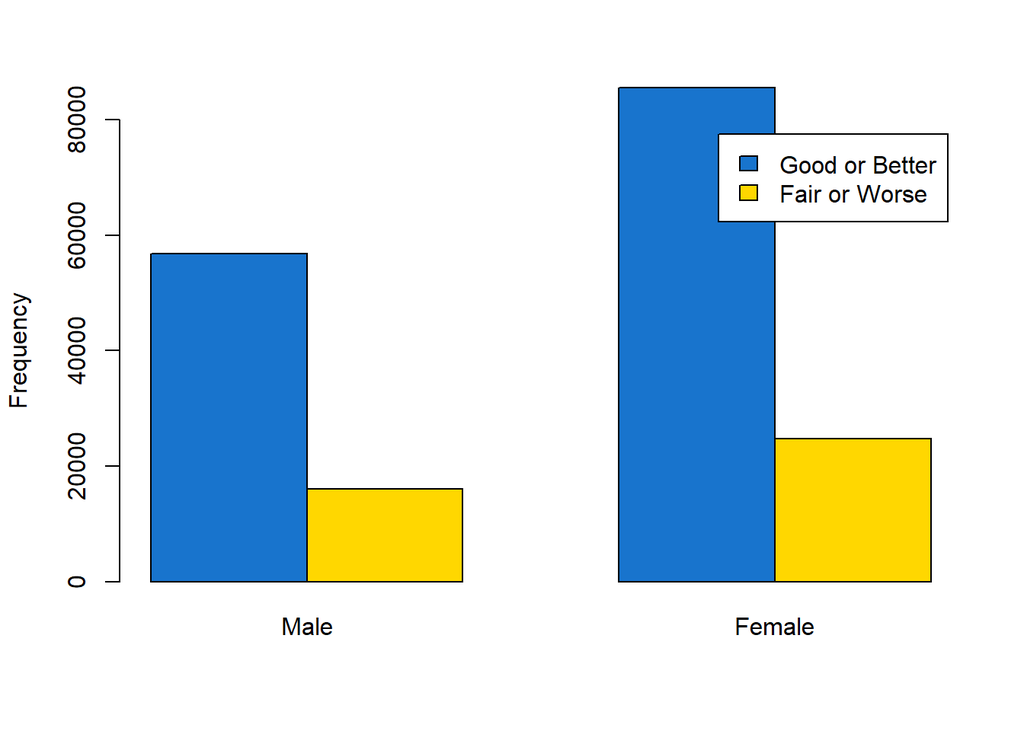

```r
barplot(freq_data,
        ylab="Frequency",
        ylim=c(0,80000),
        col = c("dodgerblue3", "gold"),
        beside=TRUE,
        legend.text = TRUE)
```

The effect size between sex and general health is negligible and the results will not be considered significant.

MARITAL V. GENERAL HEALTH.

```r
#Demographics. Socioeconomic characteristics. MARITAL.
freq_data <- table(data$X_RFHLTH, data$MARITAL)
colnames(freq_data) <- c("Married", "Divorced", "Widowed", "Separated",
                      "Never Married", "Common Law")
rownames(freq_data)<-c("Good or Better", "Fair or Worse")

Xsq <- chisq.test(freq_data)
print(Xsq)
```

```
##
##  Pearson's Chi-squared test
##
## data:  freq_data
## X-squared = 2479.9, df = 5, p-value < 2.2e-16
```

```r
CramerV(freq_data) #small effect
```

```
## [1] 0.1165305
```

```r
#Post-hocs.
freq_data_ph <- table(data$MARITAL, data$X_RFHLTH)
rownames(freq_data_ph) <- c("Married", "Divorced", "Widowed", "Separated",
                      "Never\nMarried", "Common\nLaw")
colnames(freq_data_ph)<-c("Good or Better", "Fair or Worse")
pairwiseNominalIndependence(freq_data_ph,
                            fisher=FALSE,
                            gtest=FALSE,
                            chisq=TRUE,
                            method="fdr")
```

```
##                      Comparison   p.Chisq p.adj.Chisq
## 1            Married : Divorced 4.58e-258   3.44e-257
## 2             Married : Widowed 2.75e-308   4.12e-307
## 3           Married : Separated 4.20e-174   2.10e-173
## 4      Married : Never\nMarried  6.06e-77    2.27e-76
## 5         Married : Common\nLaw  2.63e-02    2.82e-02
## 6            Divorced : Widowed  2.86e-02    2.86e-02
## 7          Divorced : Separated  6.90e-45    1.29e-44
## 8     Divorced : Never\nMarried  1.11e-04    1.39e-04
## 9        Divorced : Common\nLaw  7.59e-12    1.26e-11
## 10          Widowed : Separated  2.51e-52    7.53e-52
## 11     Widowed : Never\nMarried  1.06e-02    1.22e-02
## 12        Widowed : Common\nLaw  3.64e-10    5.46e-10
## 13   Separated : Never\nMarried  4.26e-52    1.06e-51
## 14      Separated : Common\nLaw  1.21e-47    2.59e-47
## 15 Never\nMarried : Common\nLaw  9.00e-07    1.23e-06
```

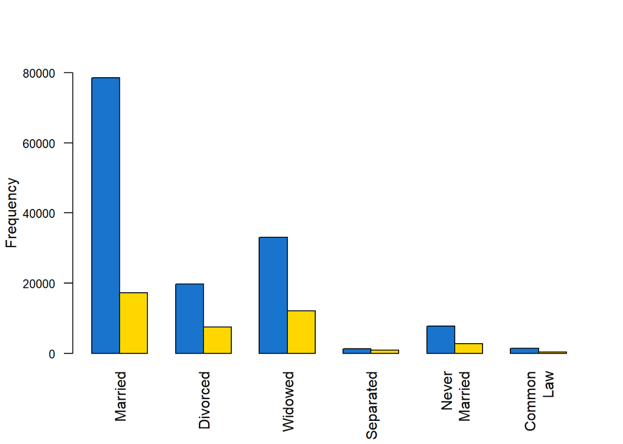

```r
barplot(freq_data,
        ylab="Frequency",
        col = c("dodgerblue3", "gold"),
        las=2,
        ylim=c(0,80000),
        names.arg = c("Married", "Divorced", "Widowed", "Separated",
                      "Never\nMarried", "Common\nLaw"),
        beside=TRUE,
        cex.axis = 0.8)
```

General health was significantly different across marital status (χ2 = 2480, p < 0.01). Cramer’s V test of effect size demonstrated a small effect between marital status and general health (V = 0.12). Adjusted post-hoc tests revealed that, except for common-law individuals, married individuals had significantly higher proportions of good or better health compared to divorced, widowed, separated, and never married individuals (p < 0.01). As well, individuals who were separated had significantly higher proportions of fair or worse health compared to the other groups (p < 0.01).

ETHNICITY V. GENERAL HEALTH.

```r
#Demographics. Socioeconomic characteristics. X_RACE.
freq_data <- table(data$X_RFHLTH, data$X_RACE)
colnames(freq_data) <- c("White", "Black", "Native", "Asian", "Native Islander","Other","Multiracial", "Hispanic")
rownames(freq_data)<-c("Good or Better", "Fair or Worse")

Xsq <- chisq.test(freq_data)
print(Xsq) # p < 0.01
```

```
##
##  Pearson's Chi-squared test
##
## data:  freq_data
## X-squared = 4189, df = 7, p-value < 2.2e-16
```

```r
CramerV(freq_data) #small
```

```
## [1] 0.1521716
```

```r
#Pairwise tests.
freq_data_ph <- table(data$X_RACE, data$X_RFHLTH)
rownames(freq_data_ph) <- c("White", "Black", "Native", "Asian", "Native\nIslander","Other","Multiracial", "Hispanic")
colnames(freq_data_ph)<-c("Good or Better", "Fair or Worse")
pairwiseNominalIndependence(freq_data_ph,
                            fisher=FALSE,
                            gtest=FALSE,
                            chisq=TRUE,
                            method="fdr")
```

```
##                        Comparison   p.Chisq p.adj.Chisq
## 1                   White : Black 6.64e-292   9.30e-291
## 2                  White : Native  2.80e-70    1.96e-69
## 3                   White : Asian  2.31e-04    3.40e-04
## 4        White : Native\nIslander  7.95e-06    1.31e-05
## 5                   White : Other  1.80e-03    2.29e-03
## 6             White : Multiracial  3.62e-43    1.27e-42
## 7                White : Hispanic  0.00e+00    0.00e+00
## 8                  Black : Native  4.98e-02    5.58e-02
## 9                   Black : Asian  1.95e-55    1.09e-54
## 10       Black : Native\nIslander  3.94e-01    4.09e-01
## 11                  Black : Other  2.41e-07    4.50e-07
## 12            Black : Multiracial  6.43e-03    7.83e-03
## 13               Black : Hispanic  4.41e-54    2.06e-53
## 14                 Native : Asian  4.81e-45    1.92e-44
## 15      Native : Native\nIslander  1.27e-01    1.37e-01
## 16                 Native : Other  1.50e-08    3.23e-08
## 17           Native : Multiracial  3.44e-04    4.82e-04
## 18              Native : Hispanic  1.37e-11    3.20e-11
## 19       Asian : Native\nIslander  1.76e-08    3.52e-08
## 20                  Asian : Other  2.72e-06    4.76e-06
## 21            Asian : Multiracial  1.91e-29    5.35e-29
## 22               Asian : Hispanic 9.22e-122   8.61e-121
## 23       Native\nIslander : Other  4.65e-02    5.42e-02
## 24 Native\nIslander : Multiracial  1.00e+00    1.00e+00
## 25    Native\nIslander : Hispanic  1.91e-05    2.97e-05
## 26            Other : Multiracial  8.61e-04    1.15e-03
## 27               Other : Hispanic  5.60e-26    1.43e-25
## 28         Multiracial : Hispanic  9.46e-34    2.94e-33
```

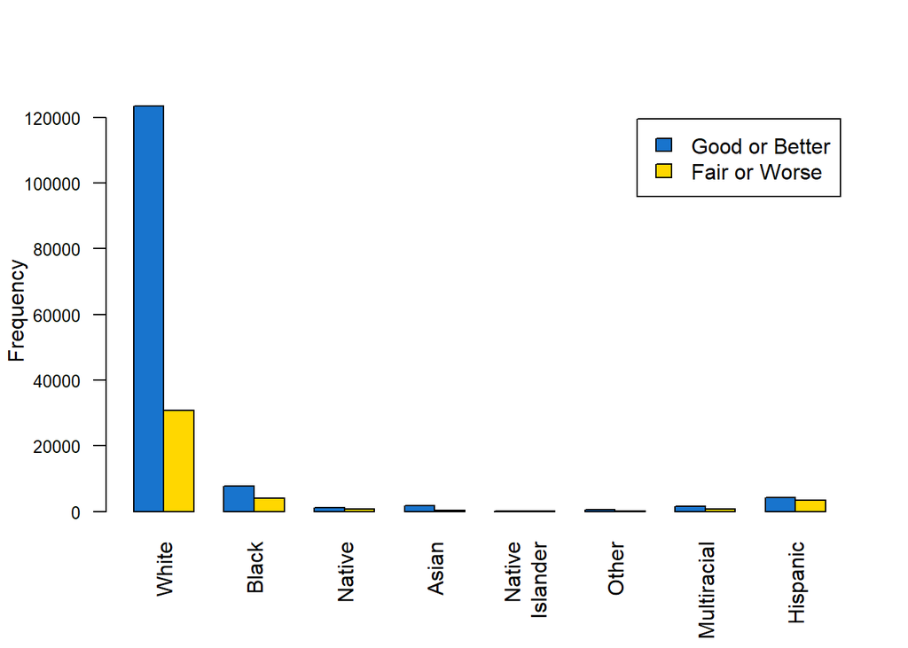

```r
barplot(freq_data,
        las=2,
        names.arg=c("White", "Black", "Native", "Asian", "Native\nIslander","Other","Multiracial", "Hispanic"),
        ylab="Frequency",
        col = c("dodgerblue3", "gold"),
        beside=TRUE,
        legend.text = TRUE,
        cex.axis = 0.8)
```

General health is significantly different across ethnicity groups (χ2 = 4189, p < 0.01). Cramer’s V test of effect size demonstrated a small effect between ethnicity and general health (V = 0.15). Adjusted post-hoc tests revealed that Caucasian and Asian individuals had significantly higher proportions of good health compared to African American, Native American, Multiracial, and Hispanic individuals (p < 0.01).

AGE V. GENERAL HEALTH.

```r
#Demographics. Socioeconomic characteristics. X_AGEG5YR.
freq_data <- table(data$X_RFHLTH, data$X_AGEG5YR)
colnames(freq_data) <- c("60-64", "65-69", "70-74","75-79", "80+")
rownames(freq_data)<-c("Good or Better", "Fair or Worse")

Xsq <- chisq.test(freq_data)
print(Xsq) # p < 0.01
```

```
##
##  Pearson's Chi-squared test
##
## data:  freq_data
## X-squared = 630.71, df = 4, p-value < 2.2e-16
```

```r
CramerV(freq_data) #negligible
```

```
## [1] 0.05867647
```

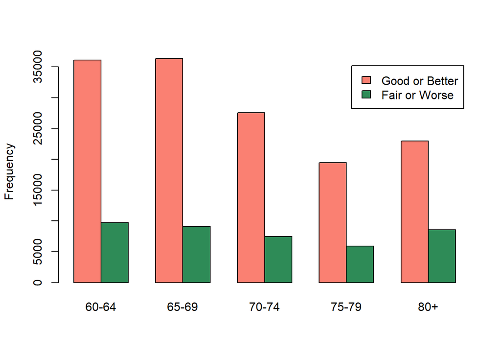

```r
barplot(freq_data,
        ylab="Frequency",
        col = c("salmon", "seagreen"),
        beside=TRUE,
        legend.text = TRUE)
```

The effect size between age and general health is negligible and the results will not be considered significant.

EDUCATION V. GENERAL HEALTH.

```r
#Demographics. Socioeconomic characteristics. X_EDUCAG.
freq_data <- table(data$X_RFHLTH, data$X_EDUCAG)
colnames(freq_data) <- c("No HS\nDiploma", "HS\nDiploma","Attended\nCollege", "College\nDiploma")
rownames(freq_data)<-c("Good or Better", "Fair or Worse")

Xsq <- chisq.test(freq_data)
print(Xsq) # p < 0.01
```

```
##
##  Pearson's Chi-squared test
##
## data:  freq_data
## X-squared = 10372, df = 3, p-value < 2.2e-16
```

```r
CramerV(freq_data) #small
```

```
## [1] 0.238172
```

```r
#Pairwise tests.
freq_data_ph <- table(data$X_EDUCAG, data$X_RFHLTH)
rownames(freq_data_ph) <- c("No HS\nDiploma", "HS\nDiploma","Attended\nCollege", "College\nDiploma")
colnames(freq_data_ph)<-c("Good or Better", "Fair or Worse")
pairwiseNominalIndependence(freq_data_ph,
                            fisher=FALSE,
                            gtest=FALSE,
                            chisq=TRUE,
                            method="fdr")
```

```
##                             Comparison   p.Chisq p.adj.Chisq
## 1         No HS\nDiploma : HS\nDiploma  0.00e+00    0.00e+00
## 2   No HS\nDiploma : Attended\nCollege  0.00e+00    0.00e+00
## 3    No HS\nDiploma : College\nDiploma  0.00e+00    0.00e+00
## 4      HS\nDiploma : Attended\nCollege 4.71e-114   4.71e-114
## 5       HS\nDiploma : College\nDiploma  0.00e+00    0.00e+00
## 6 Attended\nCollege : College\nDiploma  0.00e+00    0.00e+00
```

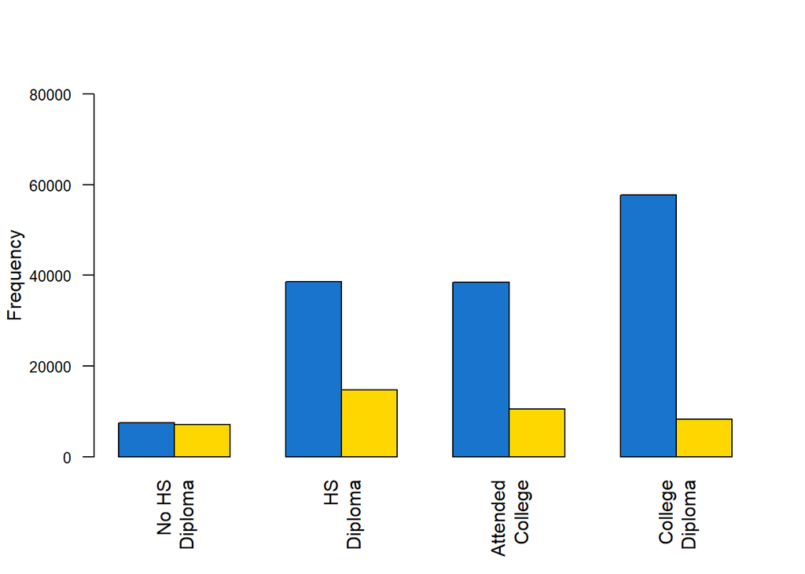

```r
barplot(freq_data,
        ylab="Frequency",
        col = c("dodgerblue3", "gold"),
        beside=TRUE,
        las=2,
        ylim=c(0,80000),
        cex.axis=0.8)
```

General health is significantly different across education levels (χ2 = 10372, p < 0.01). Cramer’s V test of effect size demonstrated a small effect between education and general health (V = 0.24). Adjusted post-hoc tests demonstrated that individuals with no high school diploma had significantly higher proportions of fair or worse health compared to other education levels (p < 0.01).

EMPLOYMENT V. GENERAL HEALTH.

```r
#Demographics. Socioeconomic characteristics. EMPLOY1.
freq_data <- table(data$X_RFHLTH, data$EMPLOY1)
colnames(freq_data) <- c("Employed", "Not\nEmployed", "Retired","Other")
rownames(freq_data)<-c("Good or Better", "Fair or Worse")

Xsq <- chisq.test(freq_data)
print(Xsq) # p < 0.01
```

```
##
##  Pearson's Chi-squared test
##
## data:  freq_data
## X-squared = 15530, df = 3, p-value < 2.2e-16
```

```r
CramerV(freq_data) #small
```

```
## [1] 0.2916754
```

```r
#Pairwise tests.
freq_data_ph <- table(data$EMPLOY1, data$X_RFHLTH)
rownames(freq_data_ph) <- c("Employed", "Not\nEmployed", "Retired","Other")
colnames(freq_data_ph)<-c("Good or Better", "Fair or Worse")
pairwiseNominalIndependence(freq_data_ph,
                            fisher=FALSE,
                            gtest=FALSE,
                            chisq=TRUE,
                            method="fdr")
```

```
##                 Comparison       p.Chisq   p.adj.Chisq
## 1 Employed : Not\nEmployed  0.000000e+00  0.000000e+00
## 2       Employed : Retired  0.000000e+00  0.000000e+00
## 3         Employed : Other 1.770237e-320 2.120036e-320
## 4  Not\nEmployed : Retired  0.000000e+00  0.000000e+00
## 5    Not\nEmployed : Other  0.000000e+00  0.000000e+00
## 6          Retired : Other  1.260000e-10  1.260000e-10
```

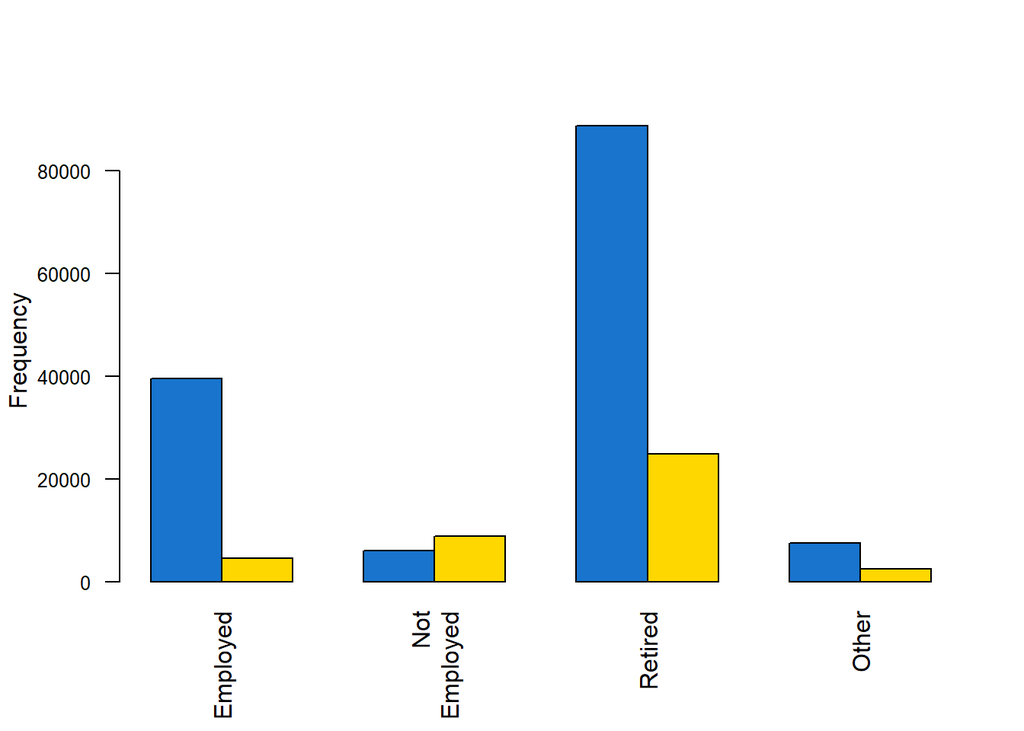

```r
barplot(freq_data,
        ylab="Frequency",
        col = c("dodgerblue3", "gold"),
        beside=TRUE,
        las=2,
        ylim=c(0,90000),
        cex.axis=0.8)
```

INCOME V. GENERAL HEALTH.

```r
#Demographics. Socioeconomic characteristics. INCOME.
freq_data <- table(data$X_RFHLTH, data$INCOME2)
colnames(freq_data) <- c("No\nReport", "<10,000", "10-15,000", "15-20,000","20-25,000", "25-35,000", "35-50,000","50-75,000", ">75,000")
rownames(freq_data)<-c("Good or Better", "Fair or Worse")

Xsq <- chisq.test(freq_data)
print(Xsq) # p < 0.01
```

```
##
##  Pearson's Chi-squared test
##
## data:  freq_data
## X-squared = 13542, df = 8, p-value < 2.2e-16
```

```r
CramerV(freq_data) #small
```

```
## [1] 0.2718925
```

```r
#Pairwise tests.
freq_data_ph <- table(data$INCOME2, data$X_RFHLTH)
rownames(freq_data_ph) <- c("No\nReport","<10,000", "10-15,000", "15-20,000","20-25,000", "25-35,000", "35-50,000","50-75,000", ">75,000")
colnames(freq_data_ph)<-c("Good or Better", "Fair or Worse")
pairwiseNominalIndependence(freq_data_ph,
                            fisher=FALSE,
                            gtest=FALSE,
                            chisq=TRUE,
                            method="fdr")
```

```
##                Comparison   p.Chisq p.adj.Chisq
## 1    No\nReport : <10,000  0.00e+00    0.00e+00
## 2  No\nReport : 10-15,000  0.00e+00    0.00e+00
## 3  No\nReport : 15-20,000 8.14e-194   1.47e-193
## 4  No\nReport : 20-25,000  7.22e-63    9.28e-63
## 5  No\nReport : 25-35,000  7.50e-02    7.50e-02
## 6  No\nReport : 35-50,000  1.05e-59    1.30e-59
## 7  No\nReport : 50-75,000 7.66e-190   1.25e-189
## 8    No\nReport : >75,000  0.00e+00    0.00e+00
## 9     <10,000 : 10-15,000  1.32e-16    1.36e-16
## 10    <10,000 : 15-20,000  2.51e-85    3.48e-85
## 11    <10,000 : 20-25,000 1.84e-197   3.49e-197
## 12    <10,000 : 25-35,000  0.00e+00    0.00e+00
## 13    <10,000 : 35-50,000  0.00e+00    0.00e+00
## 14    <10,000 : 50-75,000  0.00e+00    0.00e+00
```

[output cut: 22 more lines]

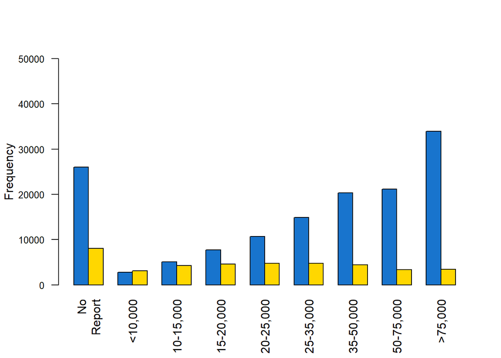

```r
barplot(freq_data,
        las=2,
        ylab="Frequency",
        col = c("dodgerblue3", "gold"),
        beside=TRUE,
        ylim=c(0,50000),
        cex.axis = 0.8)
```

VETERAN STATUS V. GENERAL HEALTH.

```r
#Demographics. Socioeconomic characteristics. VETERAN3.

freq_data <- table(data$X_RFHLTH, data$VETERAN3)
colnames(freq_data) <- c("Veteran", "Non-Veteran")
rownames(freq_data)<-c("Good or Better", "Fair or Worse")

Xsq <- chisq.test(freq_data)
print(Xsq) # p < 0.01
```

```
##
##  Pearson's Chi-squared test with Yates' continuity correction
##
## data:  freq_data
## X-squared = 12.126, df = 1, p-value = 0.0004972
```

```r
CramerV(freq_data) #Negligible. No interpretation.
```

```
## [1] 0.008154272
```

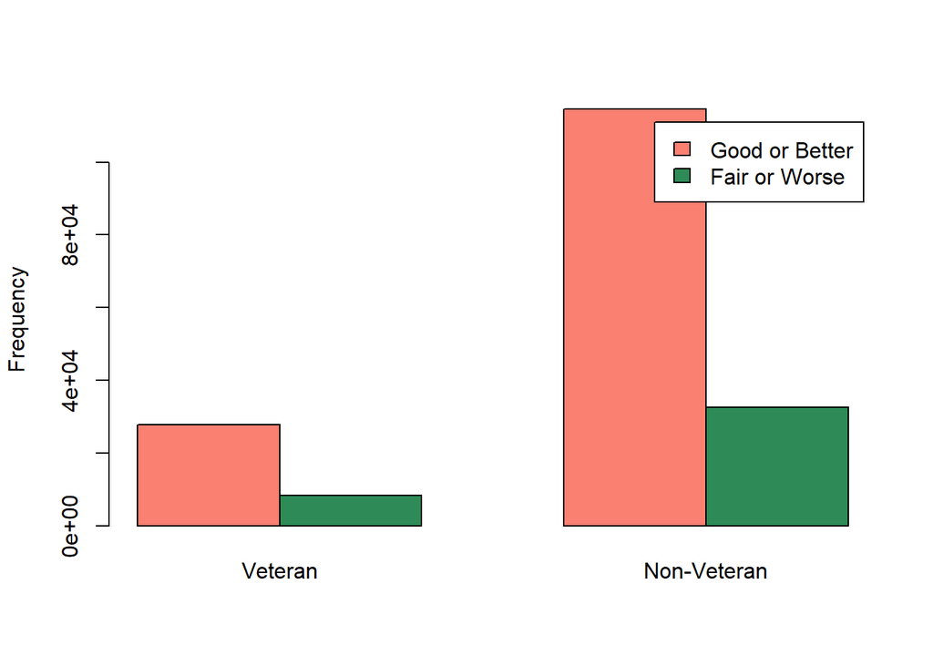

```r
barplot(freq_data,
        ylab="Frequency",
        col = c("salmon", "seagreen"),
        beside=TRUE,
        legend.text = TRUE)
```

The effect size between veteran status and general health is negligible and the results will not be considered significant.

HEALTH PLANs V. GENERAL HEALTH.

```r
#Demographics. Socioeconomic status. HLTHPLN1.

freq_data <- table(data$X_RFHLTH, data$HLTHPLN1)
colnames(freq_data) <- c("Yes", "No")
rownames(freq_data)<-c("Good or Better", "Fair or Worse")

Xsq <- chisq.test(freq_data)
print(Xsq) # p < 0.01
```

```
##
##  Pearson's Chi-squared test with Yates' continuity correction
##
## data:  freq_data
## X-squared = 117.47, df = 1, p-value < 2.2e-16
```

```r
CramerV(freq_data) #Negligible. No interpretation.
```

```
## [1] 0.0253838
```

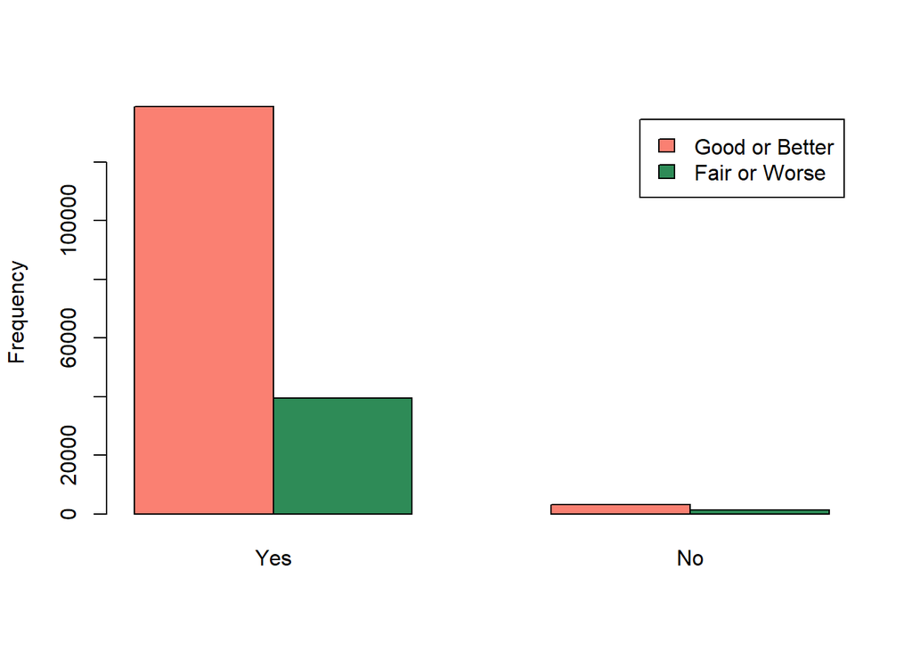

```r
barplot(freq_data,
        ylab="Frequency",
        col = c("salmon", "seagreen"),
        beside=TRUE,
        legend.text = TRUE)
```

The effect size between health plan status and general health is negligible and the results will not be considered significant.

MEDICAL COSTS V. GENERAL HEALTH.

```r
#Demographics. Socioeconomic status. MEDCOST.
freq_data <- table(data$X_RFHLTH, data$MEDCOST)
colnames(freq_data) <- c("Yes", "No")
rownames(freq_data)<-c("Good or Better", "Fair or Worse")

Xsq <- chisq.test(freq_data)
print(Xsq) # p < 0.01
```

```
##
##  Pearson's Chi-squared test with Yates' continuity correction
##
## data:  freq_data
## X-squared = 3382.8, df = 1, p-value < 2.2e-16
```

```r
CramerV(freq_data) #Small.
```

```
## [1] 0.1360473
```

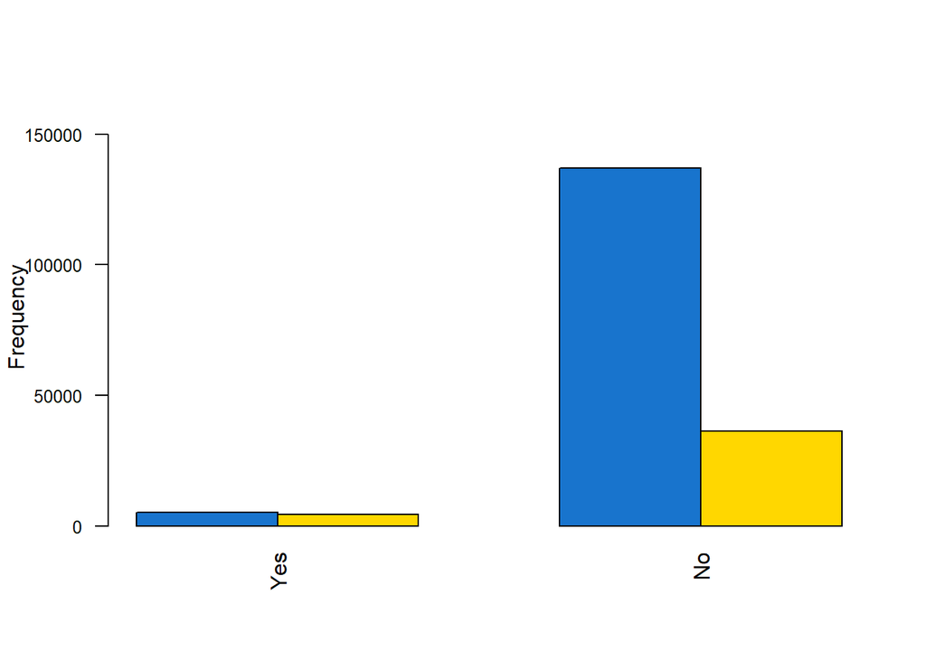

```r
barplot(freq_data,
        las=2,
        ylab="Frequency",
        col = c("dodgerblue3", "gold"),
        beside=TRUE,
        ylim=c(0,160000),
        cex.axis = 0.8)
```

Respondents who were unable to see doctor because of medical costs had significantly higher proportions of fair or worse health compared to individuals who were able to see a doctor despite the costs (χ2 = 3383, p < 0.01, V = 0.13).

NUMBER OF ADULTS IN HOME V. GENERAL HEALTH.

```r
#Demographics. Living Situation. ADULT.
wilcox.test(data$X_RFHLTH, data$ADULT,
            paired=FALSE, na.rm = TRUE) # p < 0.01
```

```
##
##  Wilcoxon rank sum test with continuity correction
##
## data:  data$X_RFHLTH and data$ADULT
## W = 1.0403e+10, p-value < 2.2e-16
## alternative hypothesis: true location shift is not equal to 0
```

```r
wilcox_effsize(data, ADULT ~ X_RFHLTH, na.rm=TRUE) #negligible
```

```
## # A tibble: 1 × 7
##   .y.   group1 group2 effsize     n1    n2 magnitude
## * <chr> <chr>  <chr>    <dbl>  <int> <int> <ord>
## 1 ADULT 1      2       0.0575 141411 40566 small
```

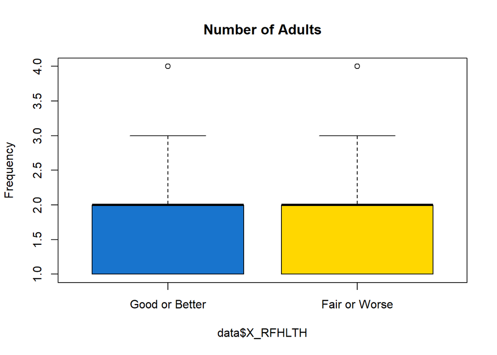

```r
boxplot(formula=data$ADULT~data$X_RFHLTH,
        ylab="Frequency",
        main="Number of Adults",
        col = c("dodgerblue3", "gold"),
        beside=TRUE,
        names=c("Good or Better", "Fair or Worse"))
```

The effect size between number of adults in the home and general health is negligible and the results will not be considered significant.

CHILDREN IN THE HOME V. GENERAL HEALTH.

```r
#Demographics. Living Situation. CHILDREN.
wilcox.test(data$X_RFHLTH, data$CHILDREN,
            paired=FALSE, na.rm = TRUE) # p < 0.01
```

```
##
##  Wilcoxon rank sum test with continuity correction
##
## data:  data$X_RFHLTH and data$CHILDREN
## W = 3.2677e+10, p-value < 2.2e-16
## alternative hypothesis: true location shift is not equal to 0
```

```r
wilcox_effsize(data, CHILDREN ~ X_RFHLTH, na.rm=TRUE) # negligible
```

```
## # A tibble: 1 × 7
##   .y.      group1 group2 effsize     n1    n2 magnitude
## * <chr>    <chr>  <chr>    <dbl>  <int> <int> <ord>
## 1 CHILDREN 1      2       0.0299 142240 40769 small
```

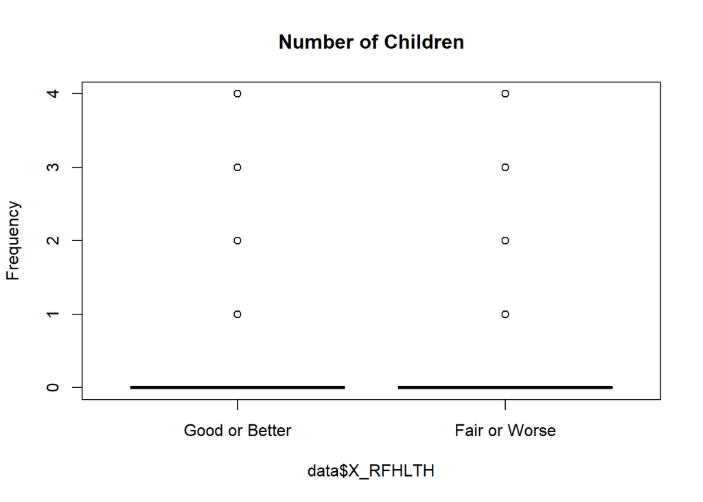

```r
boxplot(formula=data$CHILDREN~data$X_RFHLTH,
        ylab="Frequency",
        main="Number of Children",
        col = c("dodgerblue3", "gold"),
        beside=TRUE,
        names=c("Good or Better", "Fair or Worse"))
```

The effect size between number of children in the home and general health is negligible and the results will not be considered significant.

HOME OWNDERSHIP V. GENERAL HEALTH.

```r
#Demographics. Living Situation. RENTHOME1.
freq_data <- table(data$X_RFHLTH, data$RENTHOM1)
colnames(freq_data) <- c("Owns", "Doesn't\nOwn")
rownames(freq_data)<-c("Good or Better", "Fair or Worse")

Xsq <- chisq.test(freq_data)
print(Xsq) # p < 0.01
```

```
##
##  Pearson's Chi-squared test with Yates' continuity correction
##
## data:  freq_data
## X-squared = 4382.7, df = 1, p-value < 2.2e-16
```

```r
CramerV(freq_data) #small
```

```
## [1] 0.1549757
```

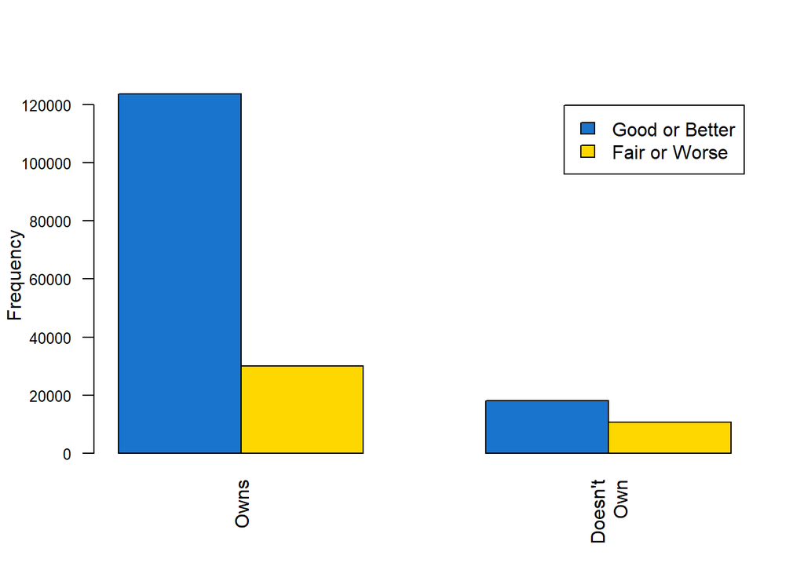

```r
barplot(freq_data,
        ylab="Frequency",
        las=2,
        col = c("dodgerblue3", "gold"),
        beside=TRUE,
        cex.axis = 0.8,
        legend.text = TRUE)
```

BMI V. GENERAL HEALTH.

```r
#Demographics. Medical Characteristics. X_BMI5.
wilcox.test(data$X_RFHLTH, data$X_BMI5,
            paired=FALSE, na.rm = TRUE) # p < 0.01
```

```
##
##  Wilcoxon rank sum test with continuity correction
##
## data:  data$X_RFHLTH and data$X_BMI5
## W = 0, p-value < 2.2e-16
## alternative hypothesis: true location shift is not equal to 0
```

```r
wilcox_effsize(data, X_BMI5 ~ X_RFHLTH, na.rm=TRUE) #small
```

```
## # A tibble: 1 × 7
##   .y.    group1 group2 effsize     n1    n2 magnitude
## * <chr>  <chr>  <chr>    <dbl>  <int> <int> <ord>
## 1 X_BMI5 1      2        0.114 135758 39027 small
```

```r
md = mean(data$X_BMI5[data$X_RFHLTH==1], na.rm=TRUE) - mean(data$X_BMI5[data$X_RFHLTH==2], na.rm=TRUE)
print(md)
```

```
## [1] -1.793455
```

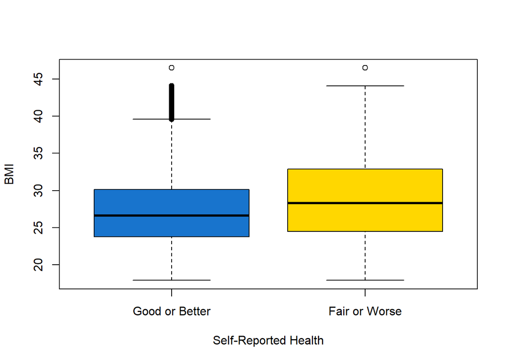

```r
boxplot(formula=data$X_BMI5~data$X_RFHLTH,
        xlab="Self-Reported Health",
        ylab="BMI",
        col = c("dodgerblue3", "gold"),
        beside=TRUE,
        names=c("Good or Better", "Fair or Worse"))
```

Individuals who report good or better health have significantly lower BMI compared to individuals who report fair or worse health (MD = -1.79, W = 0, p < 0.01). The Wilcoxon test of effect size demonstrated a small effect between BMI and general health (r = 0.11).

BLOOD PRESSURE V. GENERAL HEALTH.

```r
#Demographics. Medical Demographics. X_RFHYPE5.
#People with normal blood pressure have higher proportions of
#good or better health.

freq_data <- table(data$X_RFHLTH, data$X_RFHYPE5)
colnames(freq_data) <- c("Normal\nBlood Pressure", "High\nBlood Pressure")
rownames(freq_data)<-c("Good or Better", "Fair or Worse")

Xsq <- chisq.test(freq_data)
print(Xsq) # p < 0.01
```

```
##
##  Pearson's Chi-squared test with Yates' continuity correction
##
## data:  freq_data
## X-squared = 5059.3, df = 1, p-value < 2.2e-16
```

```r
CramerV(freq_data) #Small.
```

```
## [1] 0.1663933
```

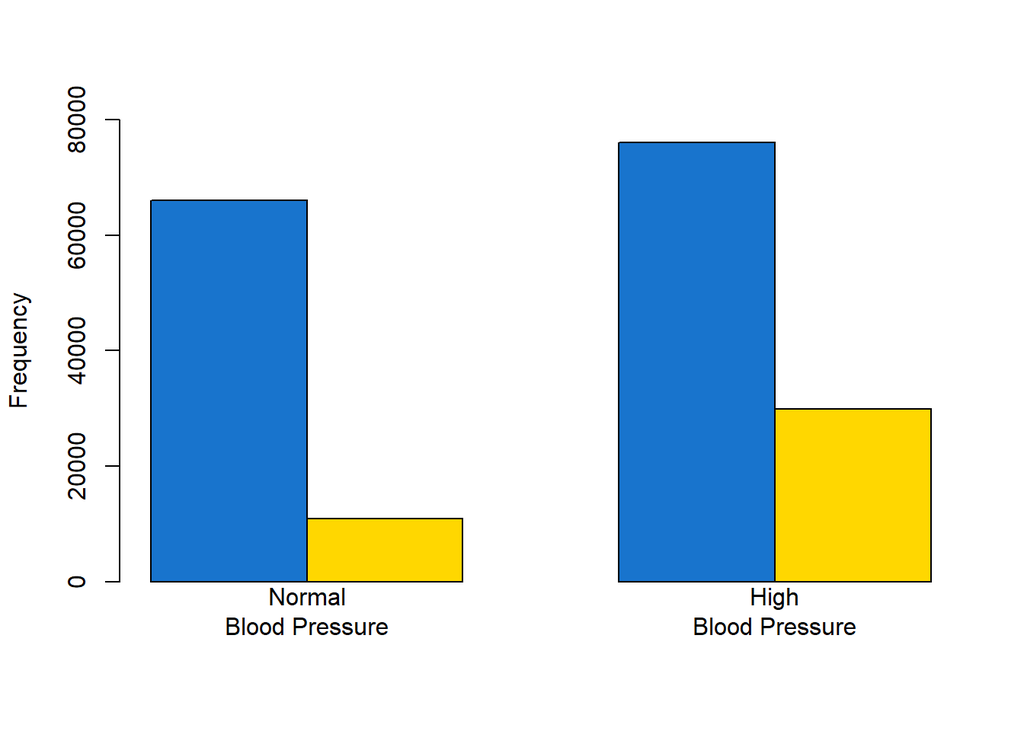

```r
barplot(freq_data,
        ylab="Frequency",
        col = c("dodgerblue3", "gold"),
        beside=TRUE,
        ylim = c(0,80000))
```

The proportions of fair or worse health were significantly higher for individuals who had a history of high blood pressure (χ2 = 5059, p < 0.01, V = 0.17).

CHOLESTEROL LEVELS V. GENERAL HEALTH.

```r
#Demographics. Medical Demographics. X_RFCHOL.

freq_data <- table(data$X_RFHLTH, data$X_RFCHOL)
colnames(freq_data) <- c("Normal\nCholesterol", "High\nCholesterol")
rownames(freq_data)<-c("Good or Better", "Fair or Worse")

Xsq <- chisq.test(freq_data)
print(Xsq) # p < 0.01
```

```
##
##  Pearson's Chi-squared test with Yates' continuity correction
##
## data:  freq_data
## X-squared = 1803.4, df = 1, p-value < 2.2e-16
```

```r
CramerV(freq_data) #small
```

```
## [1] 0.1017433
```

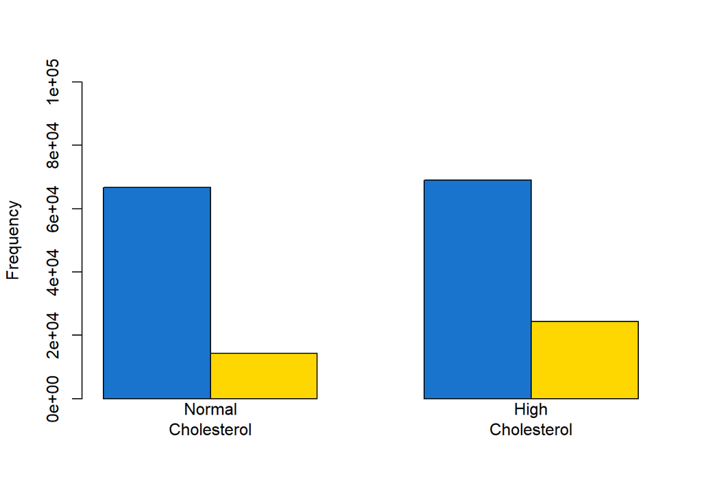

```r
barplot(freq_data,
        ylab="Frequency",
        col = c("dodgerblue3", "gold"),
        beside=TRUE,
        ylim = c(0,100000))
```

The proportions of fair or worse health were significantly higher for individuals who had a history of high cholesterol (χ2 = 1803, p < 0.01, V = 0.10).

HEART DISEASE OR MYOCARDIAL INFARCTION V. GENERAL HEALTH.

```r
#Demographics. Medical Demographics. X_MICHD.
freq_data <- table(data$X_RFHLTH, data$X_MICHD)
colnames(freq_data) <- c("HD/MI History", "No HD/MI\nHistory")
rownames(freq_data)<-c("Good or Better", "Fair or Worse")

Xsq <- chisq.test(freq_data)
print(Xsq) # p < 0.01
```

```
##
##  Pearson's Chi-squared test with Yates' continuity correction
##
## data:  freq_data
## X-squared = 9827.6, df = 1, p-value < 2.2e-16
```

```r
CramerV(freq_data) #Small.
```

```
## [1] 0.2328164
```

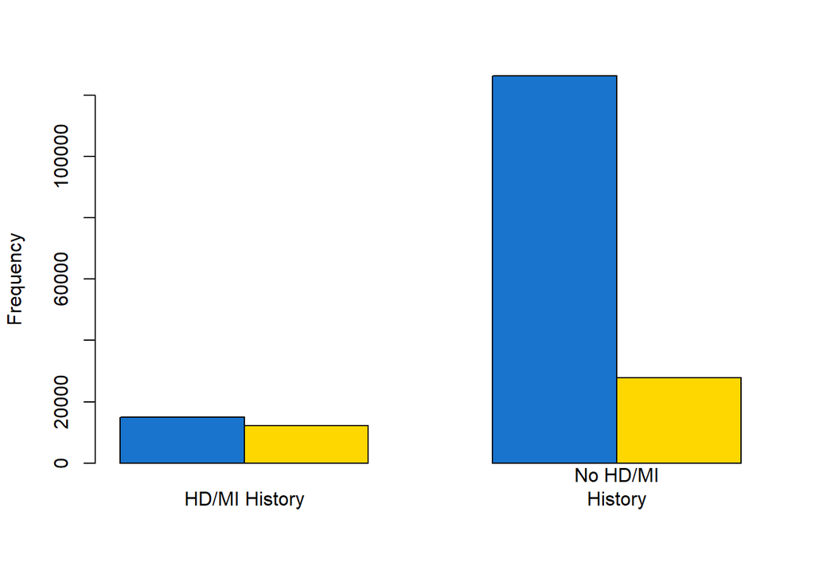

```r
barplot(freq_data,
        ylab="Frequency",
        col = c("dodgerblue3", "gold"),
        beside=TRUE,
        ylim = c(0,120000))
```

The proportions of fair or worse health were significantly higher for individuals who had a history of heart disease or myocardial infarction (χ2 = 9828, p < 0.01, V = 0.23).

STROKE HISTORY V. GENERAL HEALTH.

```r
#Demographics. Medical Demographics. CVDSTRK3.
#People who have had a stroke have higher proportions of Fair or Worse
#health.

freq_data <- table(data$X_RFHLTH, data$CVDSTRK3)
colnames(freq_data) <- c("Stroke History", "No Stroke\nHistory")
rownames(freq_data)<-c("Good or Better", "Fair or Worse")

Xsq <- chisq.test(freq_data)
print(Xsq) # p < 0.01
```

```
##
##  Pearson's Chi-squared test with Yates' continuity correction
##
## data:  freq_data
## X-squared = 4596.6, df = 1, p-value < 2.2e-16
```

```r
CramerV(freq_data) #Small.
```

```
## [1] 0.1586567
```

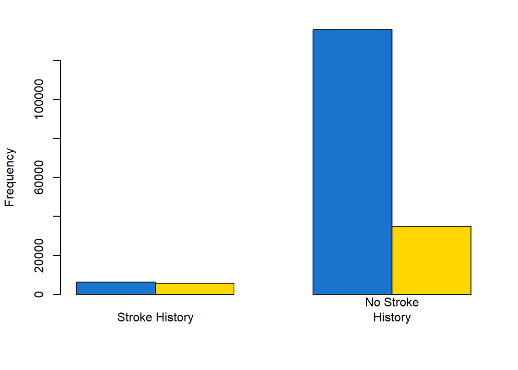

```r
barplot(freq_data,
        ylab="Frequency",
        col = c("dodgerblue3", "gold"),
        beside=TRUE,
        ylim = c(0,120000))
```

The proportions of fair or worse health were significantly higher for individuals who had a history of strokes (χ2 = 4597, p < 0.01, V = 0.16).

ASTHMA V. GENERAL HEALTH.

```r
#Demographics. Medical Demographics. X_ASTHMA1.
#People with no asthma have higher proportions of
#good or better health.

freq_data <- table(data$X_RFHLTH, data$X_ASTHMS1)
colnames(freq_data) <- c("Has Asthma", "Doesn't\nHave Asthma")
rownames(freq_data)<-c("Good or Better", "Fair or Worse")

Xsq <- chisq.test(freq_data)
print(Xsq) # p < 0.01
```

```
##
##  Pearson's Chi-squared test with Yates' continuity correction
##
## data:  freq_data
## X-squared = 2955.6, df = 1, p-value < 2.2e-16
```

```r
CramerV(freq_data) #Small.
```

```
## [1] 0.127453
```

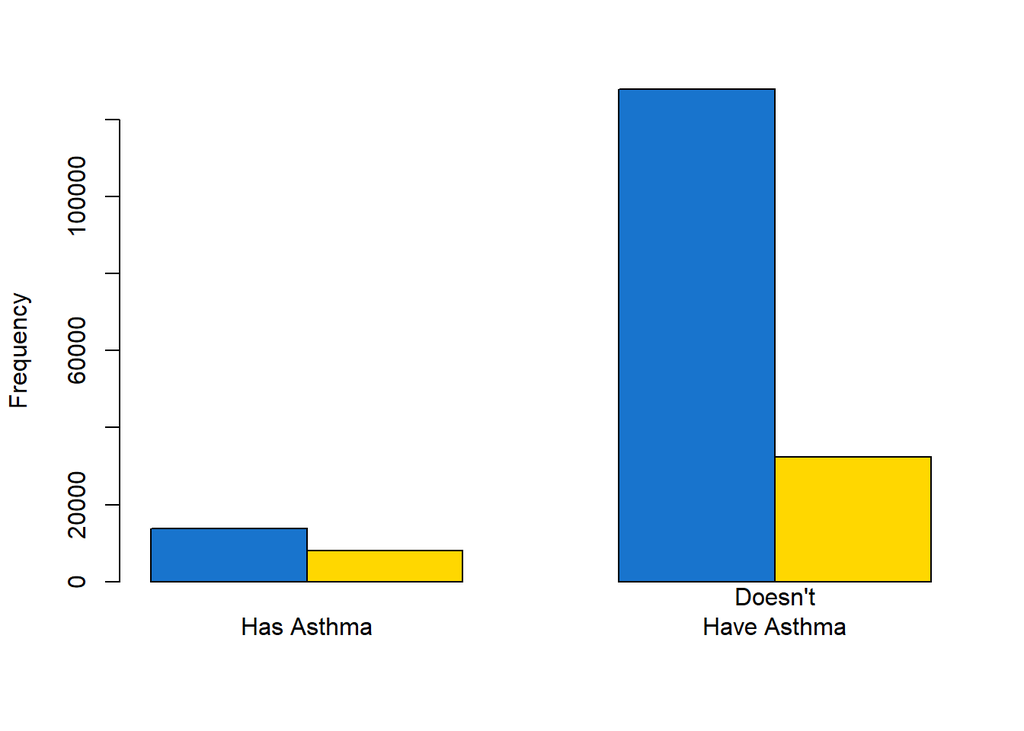

```r
barplot(freq_data,
        ylab="Frequency",
        col = c("dodgerblue3", "gold"),
        beside=TRUE,
        ylim = c(0,120000))
```

The proportions of fair or worse health were significantly higher for individuals who had a history of asthma (χ2 = 2956, p < 0.01, V = 0.13).

CANCER V. GENERAL HEALTH.

```r
#Demographics. Medical Demographics. CNCER.

freq_data <- table(data$X_RFHLTH, data$CNCER)
colnames(freq_data) <- c("Cancer History", "No Cancer\nHistory")
rownames(freq_data)<-c("Good or Better", "Fair or Worse")

Xsq <- chisq.test(freq_data)
print(Xsq) # p < 0.01
```

```
##
##  Pearson's Chi-squared test with Yates' continuity correction
##
## data:  freq_data
## X-squared = 714.95, df = 1, p-value < 2.2e-16
```

```r
CramerV(freq_data) #negligible.
```

```
## [1] 0.06260873
```

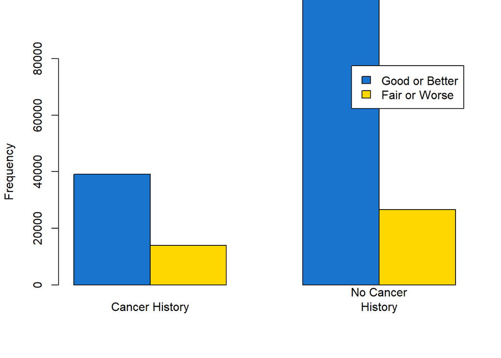

```r
barplot(freq_data,
        ylab="Frequency",
        col = c("dodgerblue3", "gold"),
        beside=TRUE,
        legend.text = TRUE,
        ylim = c(0,80000))
```

The effect size between cancer status and general health is negligible and will not be considered significant.

COPD, EMPHYSEMA, OR CHRONIC BRONCHITIS V. GENERAL HEALTH.

```r
#Demographics. Medical Demographics. CHCCOPD1.
#People with history of lung disease have higher proportions of
#fair or worse general health.

freq_data <- table(data$X_RFHLTH, data$CHCCOPD1)
colnames(freq_data) <- c("Lung Disease History", "No Lung\nDisease History")
rownames(freq_data)<-c("Good or Better", "Fair or Worse")

Xsq <- chisq.test(freq_data)
print(Xsq) # p < 0.01
```

```
##
##  Pearson's Chi-squared test with Yates' continuity correction
##
## data:  freq_data
## X-squared = 11962, df = 1, p-value < 2.2e-16
```

```r
CramerV(freq_data) #Small.
```

```
## [1] 0.2561944
```

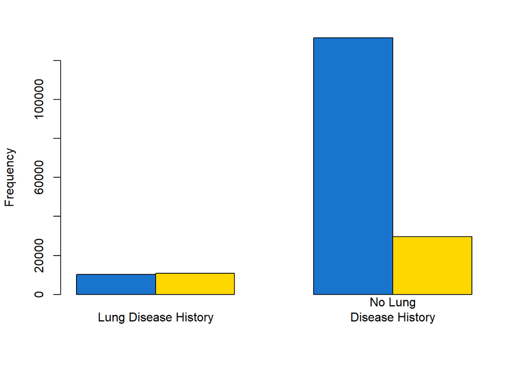

```r
barplot(freq_data,
        ylab="Frequency",
        col = c("dodgerblue3", "gold"),
        beside=TRUE,
        ylim = c(0,120000))
```

The proportions of fair or worse health were significantly higher for individuals who had a history of COPD, emphysema, or chronic bronchitis (χ2 = 11962, p < 0.01, V = 0.26).

ARTHRITIS V. GENERAL HEALTH.

```r
#Demographics. Medical Demographics. X_DRDXAR1.
#People with arthritis have higher proportions of "Fair or Worse" #health.

freq_data <- table(data$X_RFHLTH, data$X_DRDXAR1)
colnames(freq_data) <- c("Has Arthritis", "No Arthritis")
rownames(freq_data)<-c("Good or Better", "Fair or Worse")

Xsq <- chisq.test(freq_data)
print(Xsq) # p < 0.01
```

```
##
##  Pearson's Chi-squared test with Yates' continuity correction
##
## data:  freq_data
## X-squared = 6706.1, df = 1, p-value < 2.2e-16
```

```r
CramerV(freq_data) #Small.
```

```
## [1] 0.1918873
```

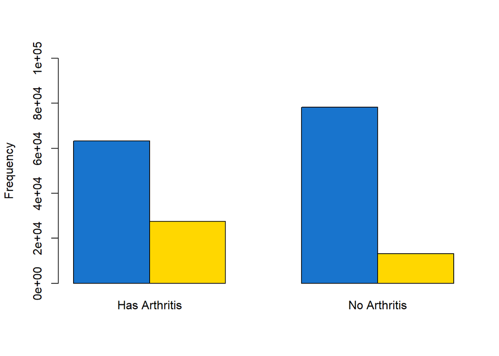

```r
barplot(freq_data,
        ylab="Frequency",
        col = c("dodgerblue3", "gold"),
        beside=TRUE,
        ylim = c(0,100000))
```

The proportions of fair or worse health were significantly higher for individuals who had a history of arthritis (χ2 = 6706, p < 0.01, V = 0.19).

DEPRESSION V. GENERAL HEALTH.

```r
#Demographics. Medical Demographics. ADDEPEV2
#People with no history of depression have higher proportions of
#good or better health.

freq_data <- table(data$X_RFHLTH, data$ADDEPEV2)
colnames(freq_data) <- c("Depression History", "No Depression\nHistory")
rownames(freq_data)<-c("Good or Better", "Fair or Worse")

Xsq <- chisq.test(freq_data)
print(Xsq) # p < 0.01
```

```
##
##  Pearson's Chi-squared test with Yates' continuity correction
##
## data:  freq_data
## X-squared = 6012.3, df = 1, p-value < 2.2e-16
```

```r
CramerV(freq_data) #Small.
```

```
## [1] 0.1814636
```

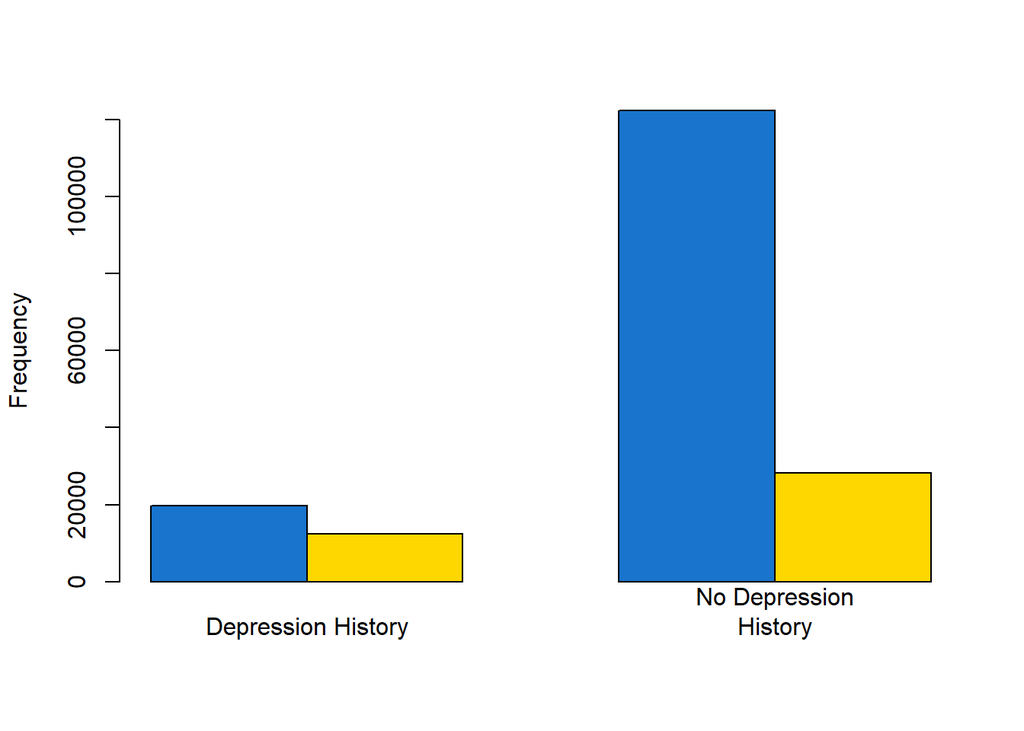

```r
barplot(freq_data,
        ylab="Frequency",
        col = c("dodgerblue3", "gold"),
        beside=TRUE,
        ylim = c(0,120000))
```

The proportions of fair or worse health were significantly higher for individuals who had a history ofdepression (χ2 =6012, p < 0.01, V = 0.18).

KIDNEY DISEASE V. GENERAL HEALTH.

```r
#Demographics. Medical Demographics. CHCKIDNY
#People with a history of kidney disease have higher proportions of
#fair or worse health.

freq_data <- table(data$X_RFHLTH, data$CHCKIDNY)
colnames(freq_data) <- c("Kidney Disease History", "No Kidney\nDisease History")
rownames(freq_data)<-c("Good or Better", "Fair or Worse")

Xsq <- chisq.test(freq_data)
print(Xsq) # p < 0.01
```

```
##
##  Pearson's Chi-squared test with Yates' continuity correction
##
## data:  freq_data
## X-squared = 4532.7, df = 1, p-value < 2.2e-16
```

```r
CramerV(freq_data) #Small.
```

```
## [1] 0.1576234
```

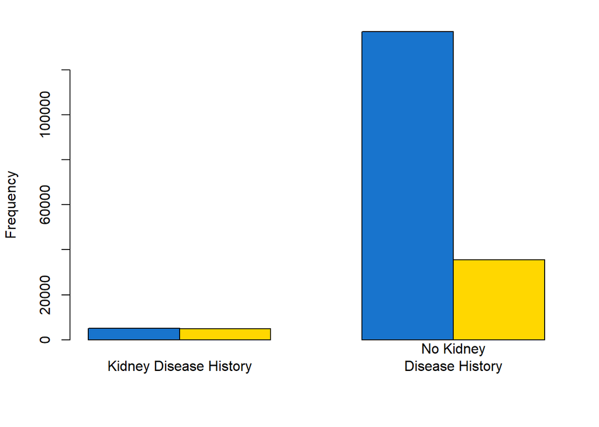

```r
barplot(freq_data,
        ylab="Frequency",
        col = c("dodgerblue3", "gold"),
        beside=TRUE,
        ylim = c(0,120000))
```

The proportions of fair or worse health were significantly higher for individuals who had a history of kidney disease (χ2 = 4533, p < 0.01, V = 0.16).

DIABETES V. GENERAL HEALTH.

```r
#Demographics. Medical Demographics. DIABETE3.
#People with no diabetes have higher proportions of
#good or better health.

freq_data <- table(data$X_RFHLTH, data$DIABETE3)
colnames(freq_data) <- c("Has Diabetes", "No Diabetes")
rownames(freq_data)<-c("Good or Better", "Fair or Worse")

Xsq <- chisq.test(freq_data)
print(Xsq) # p < 0.01
```

```
##
##  Pearson's Chi-squared test with Yates' continuity correction
##
## data:  freq_data
## X-squared = 8626, df = 1, p-value < 2.2e-16
```

```r
CramerV(freq_data) #Small.
```

```
## [1] 0.2171391
```

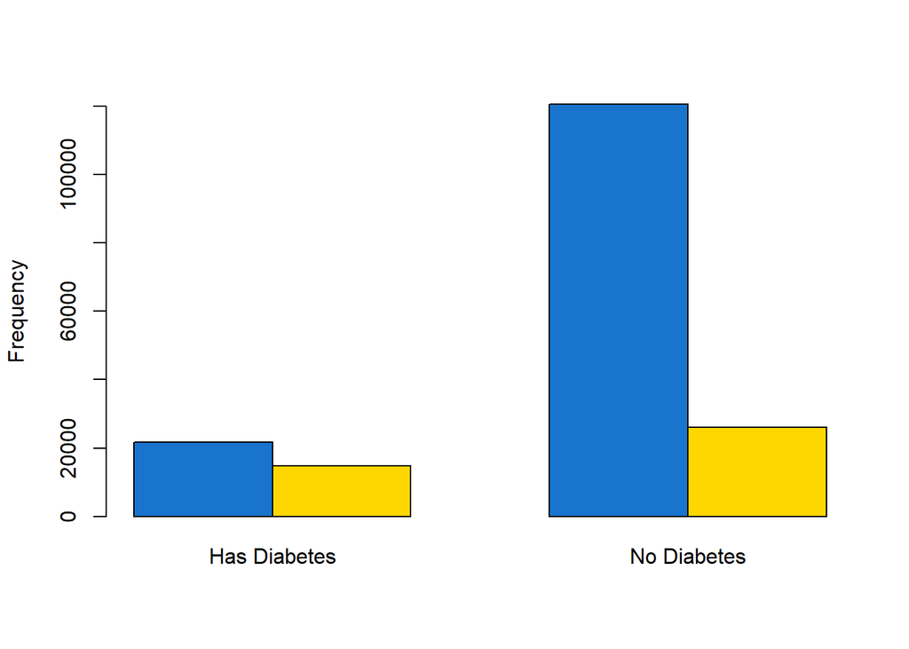

```r
barplot(freq_data,
        ylab="Frequency",
        col = c("dodgerblue3", "gold"),
        beside=TRUE,
        ylim = c(0,120000))
```

The proportions of fair or worse health were significantly higher for individuals who had a history of diabetes (χ2 =8626, p < 0.01, V = 0.22).

BLINDNESS V. GENERAL HEALTH.

```r
#Demographics. Medical Demographics. BLIND.
#Blind individuals have higher proportions of fair or worse health.

freq_data <- table(data$X_RFHLTH, data$BLIND)
colnames(freq_data) <- c("Blind", "Not Blind")
rownames(freq_data)<-c("Good or Better", "Fair or Worse")

Xsq <- chisq.test(freq_data)
print(Xsq) # p < 0.01
```

```
##
##  Pearson's Chi-squared test with Yates' continuity correction
##
## data:  freq_data
## X-squared = 6166.5, df = 1, p-value < 2.2e-16
```

```r
CramerV(freq_data) #Small.
```

```
## [1] 0.183705
```

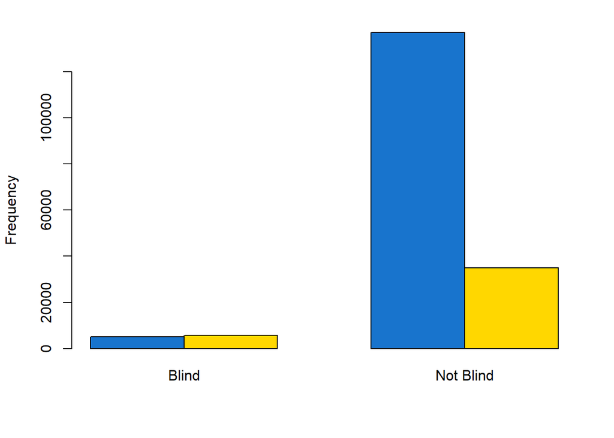

```r
# pairwise.prop.test(freq_data) TK

barplot(freq_data,
        ylab="Frequency",
        col = c("dodgerblue3", "gold"),
        beside=TRUE,
        ylim = c(0,120000))
```

The proportions of fair or worse health were significantly higher for individuals who were blind (χ2 =6166, p < 0.01, V = 0.18).

DAYS IN POOR PHYSICAL HEALTH V. GENERAL HEALTH.

```r
#Health and wellness. PHYSHLTH.
wilcox.test(data$X_RFHLTH, data$PHYSHLTH,
            paired=FALSE, na.rm = TRUE) # p < 0.01
```

```
##
##  Wilcoxon rank sum test with continuity correction
##
## data:  data$X_RFHLTH and data$PHYSHLTH
## W = 2.1284e+10, p-value < 2.2e-16
## alternative hypothesis: true location shift is not equal to 0
```

```r
wilcox_effsize(data, PHYSHLTH ~ X_RFHLTH, na.rm=TRUE) # medium
```

```
## # A tibble: 1 × 7
##   .y.      group1 group2 effsize     n1    n2 magnitude
## * <chr>    <chr>  <chr>    <dbl>  <int> <int> <ord>
## 1 PHYSHLTH 1      2        0.488 140104 38815 moderate
```

```r
md <- mean(data$PHYSHLTH[data$X_RFHLTH==1], na.rm = TRUE) - mean(data$PHYSHLTH[data$X_RFHLTH==2], na.rm = TRUE)
print(md)
```

```
## [1] -12.41945
```

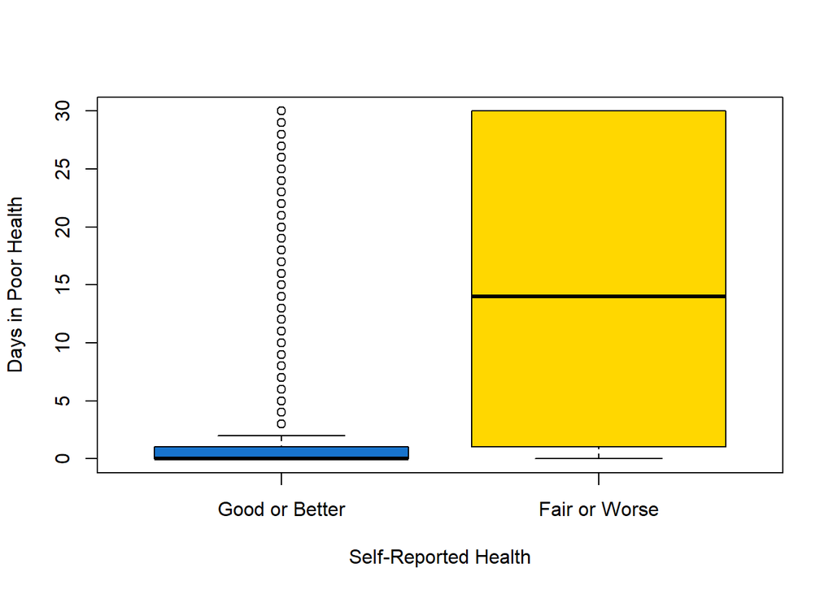

```r
boxplot(formula=data$PHYSHLTH~data$X_RFHLTH,
        ylab="Days in Poor Health",
        xlab="Self-Reported Health",
        col = c("dodgerblue3", "gold"),
        beside=TRUE,
        names=c("Good or Better", "Fair or Worse"))
```

Individuals who reported good or better health spent, on average, significantly fewer days in poor health (MD = -12.42, W = 2.13x1010, p < 0.01). ). The Wilcoxon test of effect size demonstrated a medium effect between physical health and general health (r = 0.48)

DAYS IN POOR MENTAL HEALTH V. GENERAL HEALTH.

```r
#Health and wellness. MENTHLTH.
wilcox.test(data$X_RFHLTH, data$MENTHLTH,
            paired=FALSE, na.rm = TRUE) # p < 0.01
```

```
##
##  Wilcoxon rank sum test with continuity correction
##
## data:  data$X_RFHLTH and data$MENTHLTH
## W = 2.6075e+10, p-value < 2.2e-16
## alternative hypothesis: true location shift is not equal to 0
```

```r
wilcox_effsize(data, MENTHLTH ~ X_RFHLTH, na.rm=TRUE) # small
```

```
## # A tibble: 1 × 7
##   .y.      group1 group2 effsize     n1    n2 magnitude
## * <chr>    <chr>  <chr>    <dbl>  <int> <int> <ord>
## 1 MENTHLTH 1      2        0.234 140734 39752 small
```

```r
mdm <- mean(data$MENTHLTH[data$X_RFHLTH==1], na.rm = TRUE) - mean(data$MENTHLTH[data$X_RFHLTH==2], na.rm = TRUE)
print(mdm)
```

```
## [1] -4.376138
```

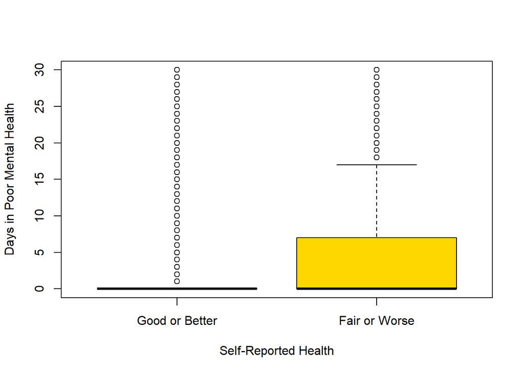

```r
boxplot(formula=data$MENTHLTH~data$X_RFHLTH,
        ylab="Days in Poor Mental Health",
        xlab="Self-Reported Health",
        col = c("dodgerblue3", "gold"),
        beside=TRUE,
        names=c("Good or Better", "Fair or Worse"))
```

Individuals who reported good or better health spent, on average, significantly fewer days in poor mental health (MD = -4.38, W = 2.61x1010, p < 0.01). The Wilcoxon test of effect size demonstrated a small effect between the number of poor mental health days and general health (r = 0.23).

ACTIVITY LIMITATIONS DUE TO HEALTH V. GENERAL HEALTH.

```r
#General Health and Wellness. QLACTLM2.
freq_data <- table(data$X_RFHLTH, data$QLACTLM2)
colnames(freq_data) <- c("Activity Limitations", "No Activity\nLimitations")
rownames(freq_data)<-c("Good or Better", "Fair or Worse")

Xsq <- chisq.test(freq_data)
print(Xsq) # p < 0.01
```

```
##
##  Pearson's Chi-squared test with Yates' continuity correction
##
## data:  freq_data
## X-squared = 26102, df = 1, p-value < 2.2e-16
```

```r
CramerV(freq_data) #medium
```

```
## [1] 0.3785368
```

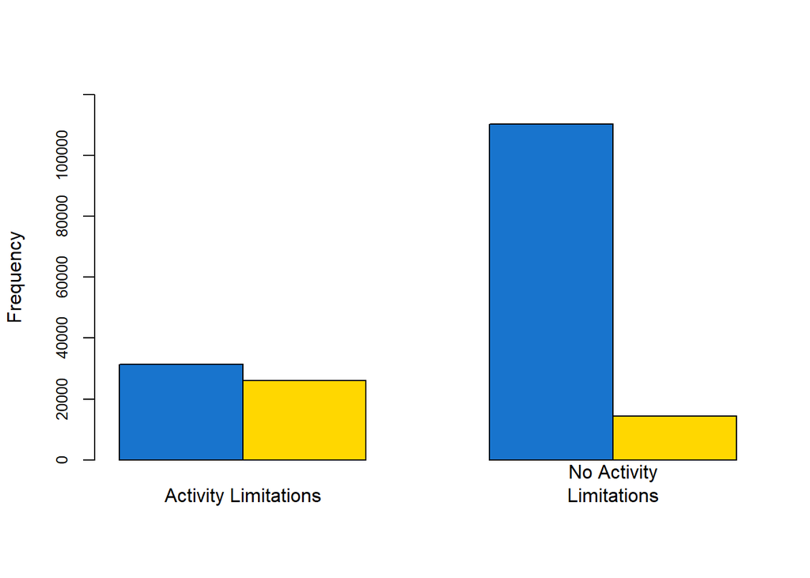

```r
barplot(freq_data,
        ylab="Frequency",
        col = c("dodgerblue3", "gold"),
        beside=TRUE,
        cex.axis = 0.8,
        ylim = c(0,120000))
```

Individuals who reported activity limitations due to health problems had significantly higher proportions of fair or worse health compared to individuals who had no activity limitations (χ2 = 26102, p < 0.01). Cramer’s V test of effect size demonstrated a medium effect between activity limitations and general health (V = 0.38).

HEALTH PROBLEMS REQUIRING SPECIAL EQUIPMENT V. GENERAL HEALTH.

```r
#General health and wellness. USEEQUIP.
#Higher frequency of "Fair or poor" health in people who report
#health problems requiring special equipment.

freq_data <- table(data$X_RFHLTH, data$USEEQUIP)
colnames(freq_data) <- c("Require Special\nEquipment", "No Special\nEquipment")
rownames(freq_data)<-c("Good or Better", "Fair or Worse")

Xsq <- chisq.test(freq_data)
print(Xsq) # p < 0.01
```

```
##
##  Pearson's Chi-squared test with Yates' continuity correction
##
## data:  freq_data
## X-squared = 21628, df = 1, p-value < 2.2e-16
```

```r
CramerV(freq_data) #medium
```

```
## [1] 0.3437749
```

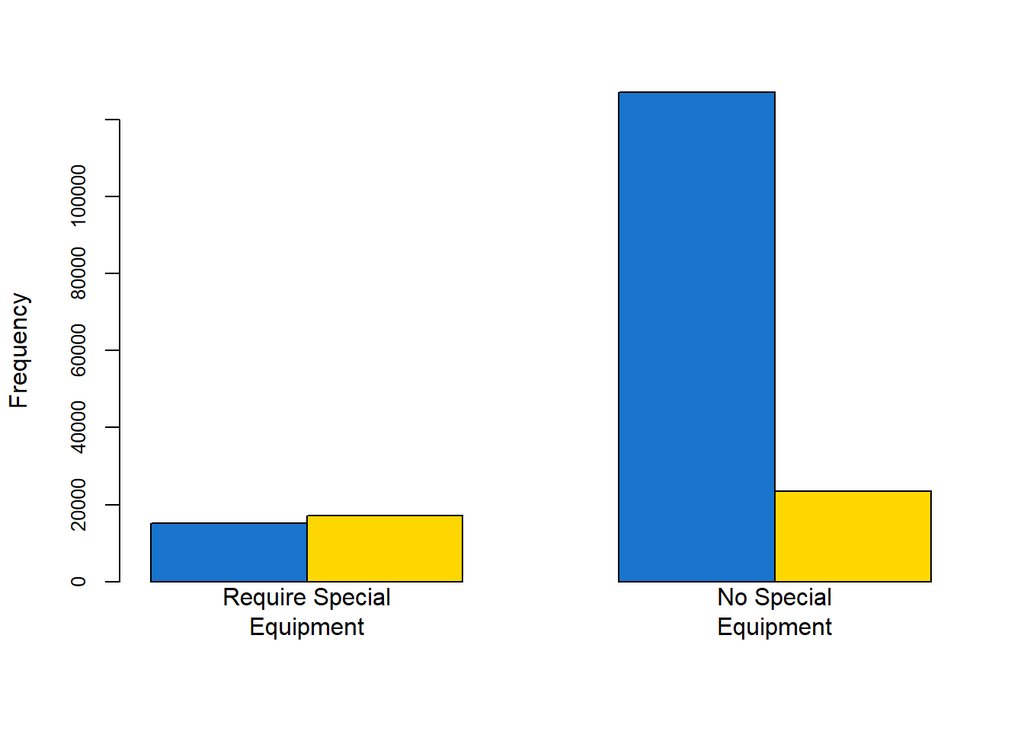

```r
barplot(freq_data,
        ylab="Frequency",
        cex.axis = 0.8,
        col = c("dodgerblue3", "gold"),
        beside=TRUE,
        ylim = c(0,120000))
```

Individuals who reported that they required special equipment due to health problems also had significantly higher proportions of fair or worse health compared to individuals who did not require special equipment (χ2 = 21628, p < 0.01). Cramer’s V test of effect size demonstrated a medium effect between special equipment and general health (V = 0.34).

COGNITIVE DEFICITS V. GENERAL HEALTH.

```r
#General health and wellness. DECIDE.
#Poeple with difficulties concentrating, remembering, or making
#decisions hav higher rates of fair or worse health.

freq_data <- table(data$X_RFHLTH, data$DECIDE)
colnames(freq_data) <- c("Cognitive Deficits", "No Cognitive\nDeficits")
rownames(freq_data)<-c("Good or Better", "Fair or Worse")

Xsq <- chisq.test(freq_data)
print(Xsq) # p < 0.01
```

```
##
##  Pearson's Chi-squared test with Yates' continuity correction
##
## data:  freq_data
## X-squared = 11537, df = 1, p-value < 2.2e-16
```

```r
CramerV(freq_data) #Small.
```

```
## [1] 0.2515582
```

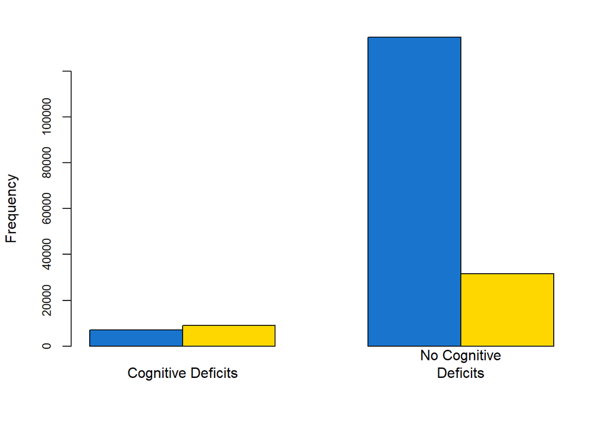

```r
barplot(freq_data,
        ylab="Frequency",
        col = c("dodgerblue3", "gold"),
        beside=TRUE,
        cex.axis = 0.8,
        ylim = c(0,120000))
```

Individuals who reported having cognitive deficits (eg, difficulties concentrating, remembering, or making decisions) had significantly higher proportions of fair or worse health compared to individuals who reported no cognitive deficits (χ2 = 11537, p < 0.01). Cramer’s V test of effect size revealed a small effect between cognitive deficits and general health (V = 0.25).

ATTENDING ROUTINE CHECKUPS V. GENERAL HEALTH.

```r
#Lifestyle behaviours. Preventative care. CHECKUP1.

freq_data <- table(data$X_RFHLTH, data$CHECKUP1)
colnames(freq_data) <- c("Did Routine Checkup", "Did Not Do\nRoutine Checkup")
rownames(freq_data)<-c("Good or Better", "Fair or Worse")

Xsq <- chisq.test(freq_data)
print(Xsq) # p < 0.01
```

```
##
##  Pearson's Chi-squared test with Yates' continuity correction
##
## data:  freq_data
## X-squared = 197.07, df = 1, p-value < 2.2e-16
```

```r
CramerV(freq_data) #Negligible.
```

```
## [1] 0.03296975
```

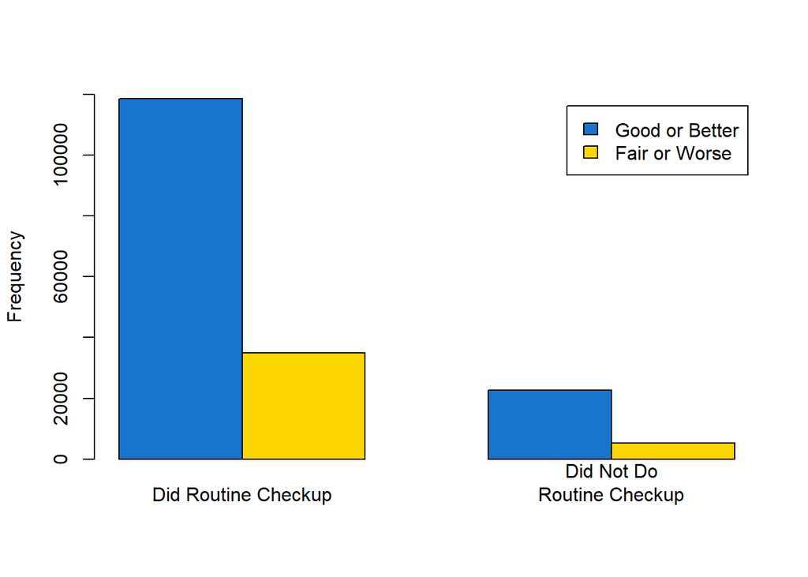

```r
barplot(freq_data,
        ylab="Frequency",
        col = c("dodgerblue3", "gold"),
        beside=TRUE,
        legend.text = TRUE,
        ylim = c(0,120000))
```

The effect size between routine checkups and general health is negligible and the results will not be considered significant.

ROUTINE FLU SHOTS V. GENERAL HEALTH.

```r
#Lifestyle behaviours. Preventative care. FLUSHOT6.

freq_data <- table(data$X_RFHLTH, data$FLUSHOT6)
colnames(freq_data) <- c("Flu Shot\nPast Year", "No Flu Shot\nPast Year")
rownames(freq_data)<-c("Good or Better", "Fair or Worse")

Xsq <- chisq.test(freq_data)
print(Xsq) # p = 0.009
```

```
##
##  Pearson's Chi-squared test with Yates' continuity correction
##
## data:  freq_data
## X-squared = 6.741, df = 1, p-value = 0.009422
```

```r
CramerV(freq_data) #Negligible.
```

```
## [1] 0.006129741
```

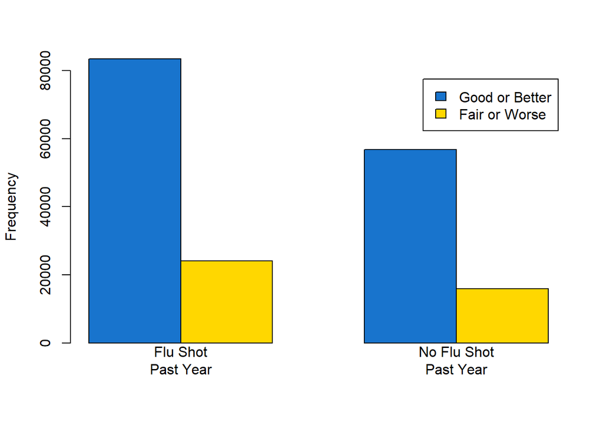

```r
barplot(freq_data,
        ylab="Frequency",
        col = c("dodgerblue3", "gold"),
        beside=TRUE,
        legend.text = TRUE,
        ylim = c(0,80000))
```

The effect size between routine flu shots and general health is negligible and the results will not be considered significant.

SMOKING V. GENERAL HEALTH.

```r
#Lifestyle behaviours. Drug and Alcohol Consumption. X_SMOKER3.

freq_data <- table(data$X_RFHLTH, data$X_SMOKER3)
colnames(freq_data) <- c("Current", "Former", "Never\nSmoked")
rownames(freq_data)<-c("Good or Better", "Fair or Worse")

Xsq <- chisq.test(freq_data)
print(Xsq) # p < 0.01
```

```
##
##  Pearson's Chi-squared test
##
## data:  freq_data
## X-squared = 2135.6, df = 2, p-value < 2.2e-16
```

```r
CramerV(freq_data) # small
```

```
## [1] 0.1082791
```

```r
#Post-hocs.
freq_data_ph <- table(data$X_SMOKER3, data$X_RFHLTH)
rownames(freq_data_ph) <- c("Current", "Former", "Never")
colnames(freq_data_ph)<-c("Good or Better", "Fair or Worse")
pairwiseNominalIndependence(freq_data_ph,
                            fisher=FALSE,
                            gtest=FALSE,
                            chisq=TRUE,
                            method="fdr")
```

```
##         Comparison   p.Chisq p.adj.Chisq
## 1 Current : Former 1.91e-172   2.86e-172
## 2  Current : Never  0.00e+00    0.00e+00
## 3   Former : Never 4.31e-126   4.31e-126
```

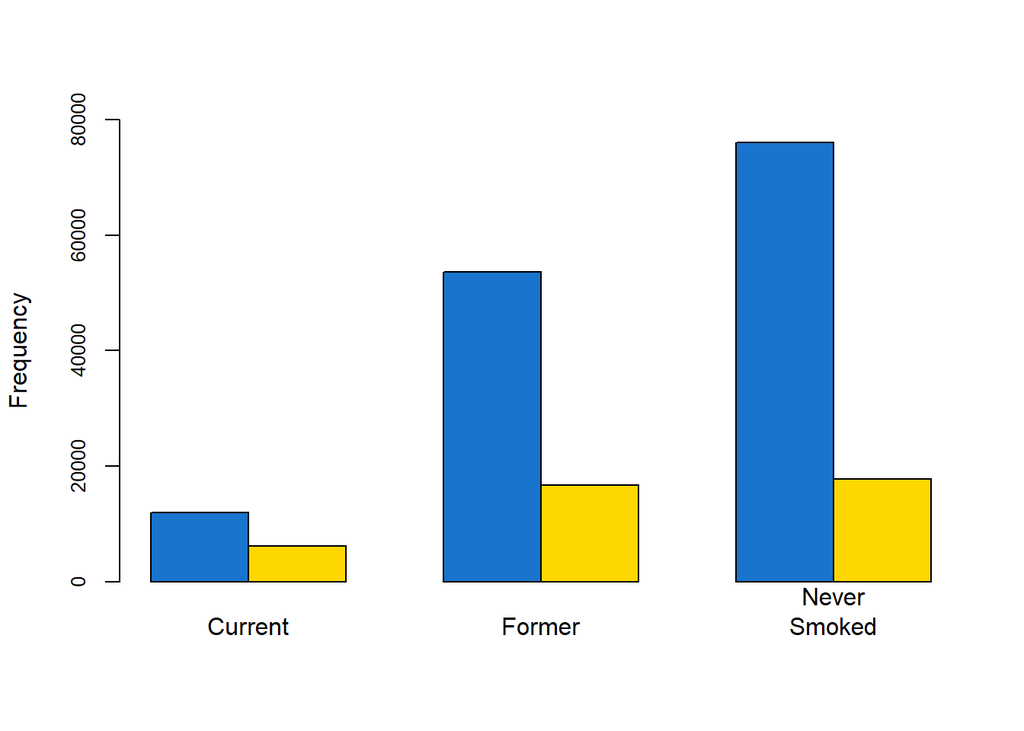

```r
barplot(freq_data,
        ylab="Frequency",
        col = c("dodgerblue3", "gold"),
        beside=TRUE,
        cex.axis = 0.8,
        ylim = c(0,80000))
```

The proportions of good or better and fair or worse health were significantly different across smoking status (χ2 = 2136, p < 0.01). Cramer’s V test of effect size demonstrated a small effect between smoking status and general health (V = 0.10). Adjusted post-hoc tests revealed that non-smokers had significantly higher proportions of good or better health compared to current and former smokers (p < 0.01), and former smokers had significantly higher proportions of good or better health compared to current smokers (p < 0.01).

AVERAGE ALCOHOL CONSUMPTION V. GENERAL HEALTH.

```r
#Lifestyle Behaviours. Drug and Alcohol Consumption. AVGDRNK.
#People with good or better health drink more on average.
wilcox.test(data$X_RFHLTH, data$AVGDRNK,
            paired=FALSE, na.rm = TRUE) # p < 0.01
```

```
##
##  Wilcoxon rank sum test with continuity correction
##
## data:  data$X_RFHLTH and data$AVGDRNK
## W = 2.4035e+10, p-value < 2.2e-16
## alternative hypothesis: true location shift is not equal to 0
```

```r
wilcox_effsize(data, AVGDRNK ~ X_RFHLTH, na.rm=TRUE) # small
```

```
## # A tibble: 1 × 7
##   .y.     group1 group2 effsize     n1    n2 magnitude
## * <chr>   <chr>  <chr>    <dbl>  <int> <int> <ord>
## 1 AVGDRNK 1      2        0.188 140275 40266 small
```

```r
mda <- mean(data$AVGDRNK[data$PHYSHLTH==1], na.rm = TRUE) - mean(data$AVGDRNK[data$PHYSHLTH==2], na.rm = TRUE)
mda
```

```
## [1] 0.2511232
```

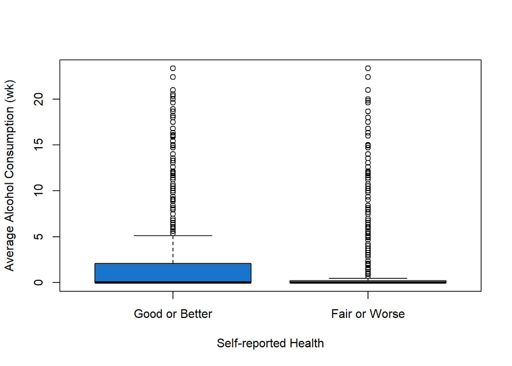

```r
boxplot(formula=data$AVGDRNK~data$X_RFHLTH,
        ylab="Average Alcohol Consumption (wk)",
        xlab="Self-reported Health",
        col = c("dodgerblue3", "gold"),
        beside=TRUE,
        names=c("Good or Better", "Fair or Worse"))
```

DAILY PHYSICAL ACTIVITY V. GENERAL HEALTH.

```r
#Lifestyle behaviours. Physical Activity. PA1MIN_
wilcox.test(data$X_RFHLTH, data$PA1MIN_,
            paired=FALSE, na.rm = TRUE) # p < 0.01
```

```
##
##  Wilcoxon rank sum test with continuity correction
##
## data:  data$X_RFHLTH and data$PA1MIN_
## W = 843930447, p-value < 2.2e-16
## alternative hypothesis: true location shift is not equal to 0
```

```r
wilcox_effsize(data, PA1MIN_ ~ X_RFHLTH, na.rm=TRUE) # negligible
```

```
## # A tibble: 1 × 7
##   .y.     group1 group2 effsize     n1    n2 magnitude
## * <chr>   <chr>  <chr>    <dbl>  <int> <int> <ord>
## 1 PA1MIN_ 1      2       0.0878 107683 20531 small
```

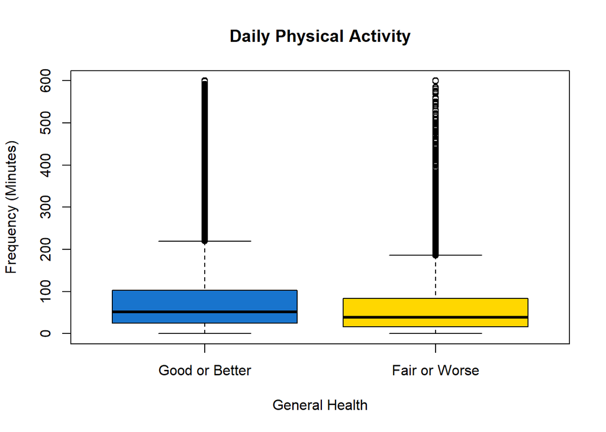

```r
boxplot(formula=data$PA1MIN_~data$X_RFHLTH,
        ylab="Frequency (Minutes)",
        xlab="General Health",
        main="Daily Physical Activity",
        col = c("dodgerblue3", "gold"),
        beside=TRUE,
        names=c("Good or Better", "Fair or Worse"))
```

The effect size between daily physical activity and general health is negligible and the results will not be considered significant.

DAILY VIGOROUS PHYSICAL ACTIVITY V. GENERAL HEALTH

```r
#Lifestyle behaviours. Physical Activity. PA1VIGM_.
wilcox.test(data$X_RFHLTH, data$PA1VIGM_,
            paired=FALSE, na.rm = TRUE) # p < 0.01
```

```
##
##  Wilcoxon rank sum test with continuity correction
##
## data:  data$X_RFHLTH and data$PA1VIGM_
## W = 1.0137e+10, p-value < 2.2e-16
## alternative hypothesis: true location shift is not equal to 0
```

```r
wilcox_effsize(data, PA1VIGM_ ~ X_RFHLTH, na.rm=TRUE) # negligible
```

```
## # A tibble: 1 × 7
##   .y.      group1 group2 effsize     n1    n2 magnitude
## * <chr>    <chr>  <chr>    <dbl>  <int> <int> <ord>
## 1 PA1VIGM_ 1      2       0.0585 108060 20651 small
```

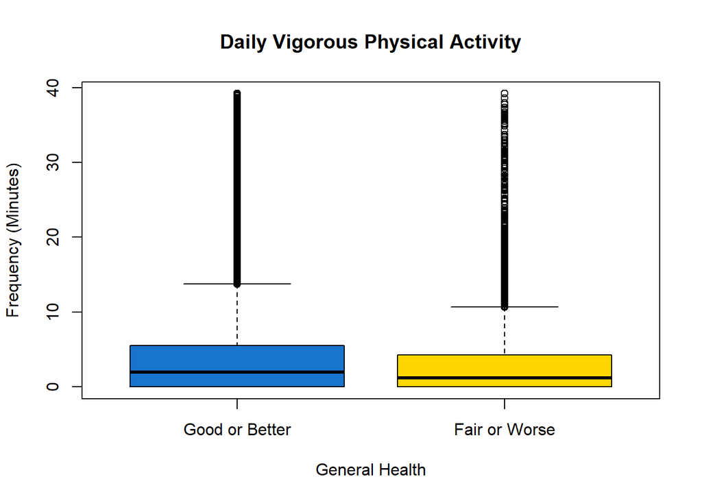

```r
boxplot(formula=data$PA1VIGM_~data$X_RFHLTH,
        ylab="Frequency (Minutes)",
        xlab="General Health",
        main="Daily Vigorous Physical Activity",
       col = c("dodgerblue3", "gold"),
        beside=TRUE,
        names=c("Good or Better", "Fair or Worse"))
```

The effect size between vigorous daily physical activity and general health is negligible and the results will not be considered significant.

MOST COMMON PHYSICAL ACTIVITY V. GENERAL HEALTH.

```r
#Lifestyle behaviours. Physical Activity. EXRACT11.

freq_data <- table(data$X_RFHLTH, data$EXRACT11)
# colnames(freq_data) <- c("", "")
rownames(freq_data)<-c("Good or Better", "Fair or Worse")

Xsq <- chisq.test(freq_data)
print(Xsq) # p < 0.01
```

```
##
##  Pearson's Chi-squared test
##
## data:  freq_data
## X-squared = 10682, df = 75, p-value < 2.2e-16
```

```r
CramerV(freq_data) #small
```

```
## [1] 0.2414713
```

```r
freq_data_ph <- table(data$EXRACT11, data$X_RFHLTH, useNA="ifany")
colnames(freq_data_ph)<-c("Good or Better", "Fair or Worse")
pairwiseNominalIndependence(freq_data_ph,
                            fisher=FALSE,
                            gtest=FALSE,
                            chisq=TRUE,
                            method="fdr")
```

```
##      Comparison   p.Chisq p.adj.Chisq
## 1         0 : 1  2.32e-04    2.10e-03
## 2         0 : 2 5.12e-206   4.79e-203
## 3         0 : 3  1.44e-01    5.17e-01
## 4         0 : 4  2.53e-02    1.32e-01
## 5         0 : 5  2.23e-10    4.63e-09
## 6         0 : 6 1.22e-104   3.42e-102
## 7         0 : 7 1.35e-157   7.57e-155
## 8         0 : 8  2.14e-07    3.18e-06
## 9         0 : 9  1.99e-25    1.24e-23
## 10       0 : 10  3.21e-03    2.14e-02
## 11       0 : 11  2.42e-73    4.85e-71
## 12       0 : 12  1.48e-03    1.09e-02
## 13       0 : 13  1.14e-05    1.26e-04
## 14       0 : 14  3.59e-58    5.92e-56
```

[output cut: 2836 more lines]

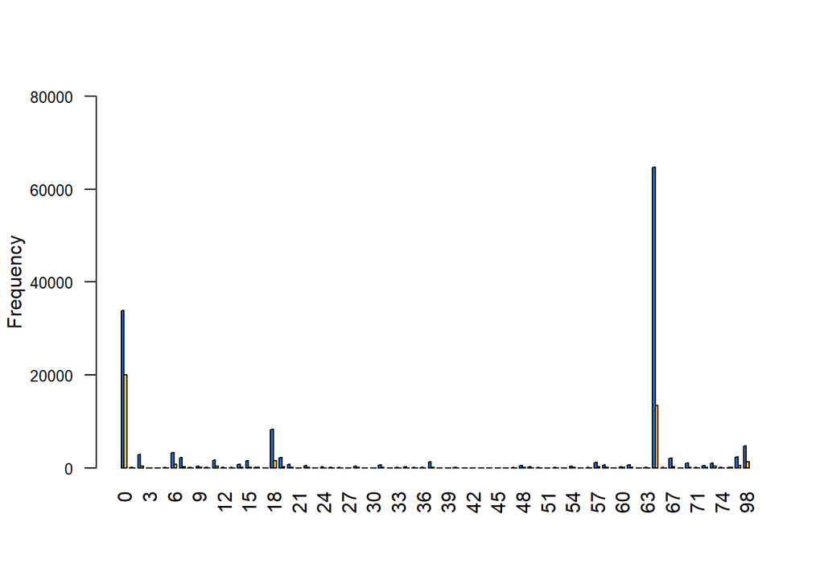

```r
barplot(freq_data,
        ylab="Frequency",
        las=2,
        cex.axis = 0.8,
        col = c("dodgerblue3", "gold"),
        beside=TRUE,
        ylim = c(0,80000)) #TK
```

The proportions of good or better and fair or worse health were significantly different across exercise types (χ2 = 10682, p < 0.01). Cramer’s V test of effect size demonstrated a small effect between exercise types and general health (V = 0.24).

STRENGTH TRAINING V. GENERAL HEALTH.

```r
#Lifestyle behaviours. Physical Activity. STRNGTH.

freq_data <- table(data$X_RFHLTH, data$STRNGTH)
colnames(freq_data) <- c("Does Strength\nTraining", "No Strength\nTraining")
rownames(freq_data)<-c("Good or Better", "Fair or Worse")

Xsq <- chisq.test(freq_data)
print(Xsq) # p < 0.01
```

```
##
##  Pearson's Chi-squared test with Yates' continuity correction
##
## data:  freq_data
## X-squared = 2335.9, df = 1, p-value < 2.2e-16
```

```r
CramerV(freq_data) #small
```

```
## [1] 0.1138789
```

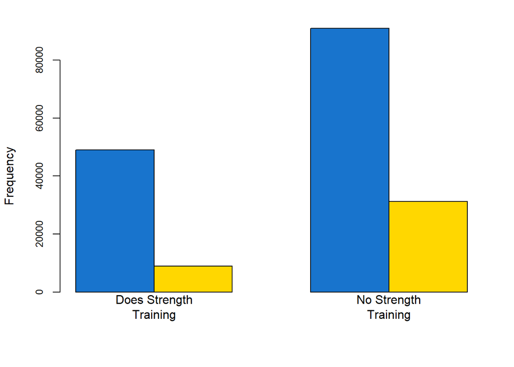

```r
barplot(freq_data,
        ylab="Frequency",
        col = c("dodgerblue3", "gold"),
        beside=TRUE,
        cex.axis = 0.8,
        ylim = c(0,80000))
```

Individuals who reported conducting strength training have significantly higher proportions of good or better health (χ2 = 2336, p < 0.01). Cramer’s V test of effect size demonstrated a small effect between strength training and general health (V = 0.11).

FRUIT CONSUMPTION V. GENERAL HEALTH.

```r
#Lifestyle behaviours. Nutrition. X_FRUTSUM.
wilcox.test(data$X_RFHLTH, data$X_FRUTSUM,
            paired=FALSE, na.rm = TRUE) # p < 0.01
```

```
##
##  Wilcoxon rank sum test with continuity correction
##
## data:  data$X_RFHLTH and data$X_FRUTSUM
## W = 1.5921e+10, p-value < 2.2e-16
## alternative hypothesis: true location shift is not equal to 0
```

```r
wilcox_effsize(data, X_FRUTSUM ~ X_RFHLTH, na.rm=TRUE) # negigible
```

```
## # A tibble: 1 × 7
##   .y.       group1 group2 effsize     n1    n2 magnitude
## * <chr>     <chr>  <chr>    <dbl>  <int> <int> <ord>
## 1 X_FRUTSUM 1      2       0.0884 138760 39443 small
```

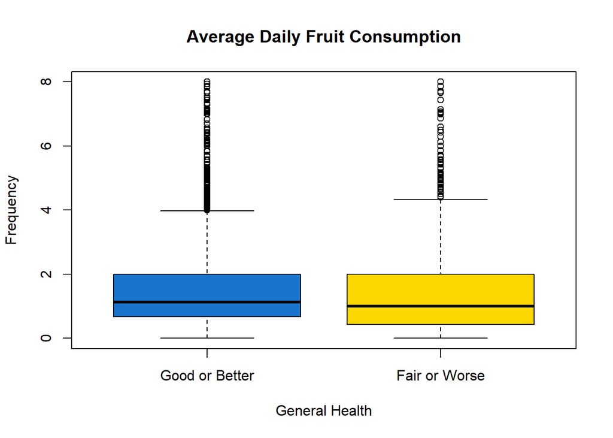

```r
boxplot(formula=data$X_FRUTSUM~data$X_RFHLTH,
        ylab="Frequency",
        xlab="General Health",
        main="Average Daily Fruit Consumption",
        col = c("dodgerblue3", "gold"),
        beside=TRUE,
        names=c("Good or Better", "Fair or Worse"))
```

The effect size between fruit consumption and general health is negligible and the results will not be considered significant.

BEAN CONSUMPTION V. GENERAL HEALTH.

```r
#Lifestyle behaviours. Nutrition. BEANDAY_
wilcox.test(data$X_RFHLTH, data$BEANDAY_,
            paired=FALSE, na.rm = TRUE) # p < 0.01
```

```
##
##  Wilcoxon rank sum test with continuity correction
##
## data:  data$X_RFHLTH and data$BEANDAY_
## W = 3.1976e+10, p-value < 2.2e-16
## alternative hypothesis: true location shift is not equal to 0
```

```r
wilcox_effsize(data, BEANDAY_ ~ X_RFHLTH, na.rm=TRUE) # negligible
```

```
## # A tibble: 1 × 7
##   .y.      group1 group2 effsize     n1    n2 magnitude
## * <chr>    <chr>  <chr>    <dbl>  <int> <int> <ord>
## 1 BEANDAY_ 1      2       0.0300 140009 40139 small
```

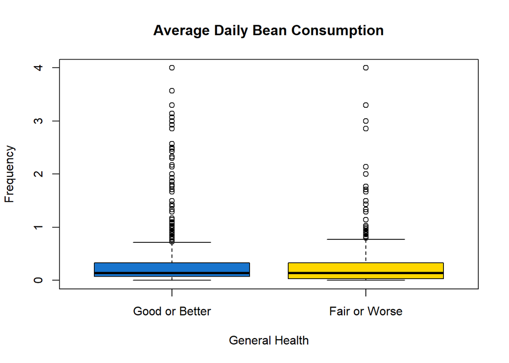

```r
boxplot(formula=data$BEANDAY_~data$X_RFHLTH,
        ylab="Frequency",
        xlab="General Health",
        main="Average Daily Bean Consumption",
        col = c("dodgerblue3", "gold"),
        beside=TRUE,
        names=c("Good or Better", "Fair or Worse"))
```

The effect size between bean activity and general health is negligible and the results will not be considered significant.

VEGETABLE CONSUMPTION V. GENERAL HEALTH.

```r
#Lifestyle behaviours. Nutrition. X_VEGESUM.
wilcox.test(data$X_RFHLTH, data$X_VEGESUM,
            paired=FALSE, na.rm = TRUE) # p < 0.01
```

```
##
##  Wilcoxon rank sum test with continuity correction
##
## data:  data$X_RFHLTH and data$X_VEGESUM
## W = 9629364062, p-value < 2.2e-16
## alternative hypothesis: true location shift is not equal to 0
```

```r
wilcox_effsize(data, X_VEGESUM ~ X_RFHLTH, na.rm=TRUE) # small
```

```
## # A tibble: 1 × 7
##   .y.       group1 group2 effsize     n1    n2 magnitude
## * <chr>     <chr>  <chr>    <dbl>  <int> <int> <ord>
## 1 X_VEGESUM 1      2        0.124 137039 38841 small
```

```r
mdv <- mean(data$X_VEGESUM[data$X_RFHLTH==1], na.rm = TRUE) - mean(data$X_VEGESUM[data$X_RFHLTH==2], na.rm = TRUE)
print(mdv)
```

```
## [1] 0.3089663
```

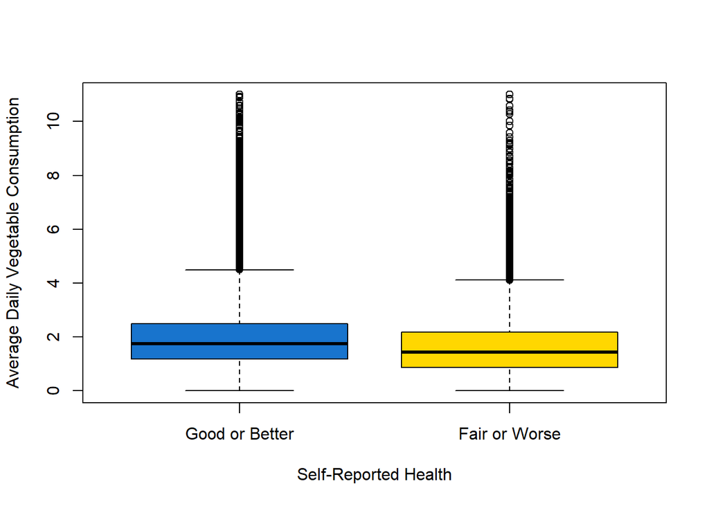

```r
boxplot(formula=data$X_VEGESUM~data$X_RFHLTH,
        ylab="Average Daily Vegetable Consumption",
        xlab="Self-Reported Health",
        col = c("dodgerblue3", "gold"),
        beside=TRUE,
        names=c("Good or Better", "Fair or Worse"))
```